# EasyVisa_Full_Code_Notebook_orig _sol

## Problem Statement

### Business Context

Business communities in the United States are facing high demand for human resources, but one of the constant challenges is identifying and attracting the right talent, which is perhaps the most important element in remaining competitive. Companies in the United States look for hard-working, talented, and qualified individuals both locally as well as abroad.

The Immigration and Nationality Act (INA) of the US permits foreign workers to come to the United States to work on either a temporary or permanent basis. The act also protects US workers against adverse impacts on their wages or working conditions by ensuring US employers' compliance with statutory requirements when they hire foreign workers to fill workforce shortages. The immigration programs are administered by the Office of Foreign Labor Certification (OFLC).

OFLC processes job certification applications for employers seeking to bring foreign workers into the United States and grants certifications in those cases where employers can demonstrate that there are not sufficient US workers available to perform the work at wages that meet or exceed the wage paid for the occupation in the area of intended employment.

### Objective

In FY 2016, the OFLC processed 775,979 employer applications for 1,699,957 positions for temporary and permanent labor certifications. This was a nine percent increase in the overall number of processed applications from the previous year. The process of reviewing every case is becoming a tedious task as the number of applicants is increasing every year.

The increasing number of applicants every year calls for a Machine Learning based solution that can help in shortlisting the candidates having higher chances of VISA approval. OFLC has hired the firm EasyVisa for data-driven solutions. You as a data scientist at EasyVisa have to analyze the data provided and, with the help of a classification model:

- Facilitate the process of visa approvals.
- Recommend a suitable profile for the applicants for whom the visa should be certified or denied based on the drivers that significantly influence the case status.

### Data Description

The data contains the different attributes of employee and the employer. The detailed data dictionary is given below.

- case_id: ID of each visa application
- continent: Information of continent the employee
- education_of_employee: Information of education of the employee
- has_job_experience: Does the employee has any job experience? Y= Yes; N = No
- requires_job_training: Does the employee require any job training? Y = Yes; N = No
- no_of_employees: Number of employees in the employer's company
- yr_of_estab: Year in which the employer's company was established
- region_of_employment: Information of foreign worker's intended region of employment in the US.
- prevailing_wage: Average wage paid to similarly employed workers in a specific occupation in the area of intended employment. The purpose of the prevailing wage is to ensure that the foreign worker is not underpaid compared to other workers offering the same or similar service in the same area of employment.
- unit_of_wage: Unit of prevailing wage. Values include Hourly, Weekly, Monthly, and Yearly.
- full_time_position: Is the position of work full-time? Y = Full Time Position; N = Part Time Position
- case_status: Flag indicating if the Visa was certified or denied

## Installing and Importing the necessary libraries

```python
# Installing the libraries with the specified version.
!pip install numpy==1.25.2 pandas==1.5.3 scikit-learn==1.5.2 matplotlib==3.7.1 seaborn==0.13.1 xgboost==2.0.3 -q --user
```

```
zsh:1: command not found: pip
```

**Note**: *After running the above cell, kindly restart the notebook kernel and run all cells sequentially from the below.*

```python
# Import necessary libraries
import numpy as np
import pandas as pd
import matplotlib.pyplot as plt
import seaborn as sns
from sklearn.model_selection import train_test_split, cross_val_score, GridSearchCV
from sklearn.preprocessing import StandardScaler
from sklearn.metrics import accuracy_score, precision_score, recall_score, f1_score, confusion_matrix
from imblearn.over_sampling import SMOTE
from imblearn.under_sampling import RandomUnderSampler
from datetime import date

# Set display options
pd.set_option('display.max_columns', None)
pd.set_option('display.max_rows', 100)
sns.set_style('whitegrid')
plt.rcParams['figure.figsize'] = (10, 6)
%matplotlib inline
```

## Import Dataset

```python
# Import the dataset
df = pd.read_csv('EasyVisa.csv')
```

## Overview of the Dataset

#### View the first and last 5 rows of the dataset

```python
# View the first 5 rows
df.head()
```

|  | case_id | continent | education_of_employee | has_job_experience | requires_job_training | no_of_employees | yr_of_estab | region_of_employment | prevailing_wage | unit_of_wage | full_time_position | case_status |
| --- | --- | --- | --- | --- | --- | --- | --- | --- | --- | --- | --- | --- |
| 0 | EZYV01 | Asia | High School | N | N | 14513 | 2007 | West | 592.2029 | Hour | Y | Denied |
| 1 | EZYV02 | Asia | Master's | Y | N | 2412 | 2002 | Northeast | 83425.6500 | Year | Y | Certified |
| 2 | EZYV03 | Asia | Bachelor's | N | Y | 44444 | 2008 | West | 122996.8600 | Year | Y | Denied |
| 3 | EZYV04 | Asia | Bachelor's | N | N | 98 | 1897 | West | 83434.0300 | Year | Y | Denied |
| 4 | EZYV05 | Africa | Master's | Y | N | 1082 | 2005 | South | 149907.3900 | Year | Y | Certified |

#### Understand the shape of the dataset

```python
# View the shape of the dataset
print(f"Shape of the dataset: {df.shape}")
print(f"Number of rows: {df.shape[0]}")
print(f"Number of columns: {df.shape[1]}")
```

```
Shape of the dataset: (25480, 12)
Number of rows: 25480
Number of columns: 12
```

#### Check the data types of the columns for the dataset

```python
# Check data types
df.info()
```

```
<class 'pandas.core.frame.DataFrame'>
RangeIndex: 25480 entries, 0 to 25479
Data columns (total 12 columns):
 #   Column                 Non-Null Count  Dtype
---  ------                 --------------  -----
 0   case_id                25480 non-null  object
 1   continent              25480 non-null  object
 2   education_of_employee  25480 non-null  object
 3   has_job_experience     25480 non-null  object
 4   requires_job_training  25480 non-null  object
 5   no_of_employees        25480 non-null  int64
 6   yr_of_estab            25480 non-null  int64
 7   region_of_employment   25480 non-null  object
 8   prevailing_wage        25480 non-null  float64
 9   unit_of_wage           25480 non-null  object
 10  full_time_position     25480 non-null  object
 11  case_status            25480 non-null  object
dtypes: float64(1), int64(2), object(9)
memory usage: 2.3+ MB
```

## Exploratory Data Analysis (EDA)

#### Let's check the statistical summary of the data

```python
# Statistical summary of numerical columns
df.describe()
```

|  | no_of_employees | yr_of_estab | prevailing_wage |
| --- | --- | --- | --- |
| count | 25480.000000 | 25480.000000 | 25480.000000 |
| mean | 5667.043210 | 1979.409929 | 74455.814592 |
| std | 22877.928848 | 42.366929 | 52815.942327 |
| min | -26.000000 | 1800.000000 | 2.136700 |
| 25% | 1022.000000 | 1976.000000 | 34015.480000 |
| 50% | 2109.000000 | 1997.000000 | 70308.210000 |
| 75% | 3504.000000 | 2005.000000 | 107735.512500 |
| max | 602069.000000 | 2016.000000 | 319210.270000 |

#### Fixing the negative values in number of employees columns

```python
# Fix negative values in number of employees column
# Replace negative values with absolute values
df['no_of_employees'] = df['no_of_employees'].abs()
print(f"Minimum value in no_of_employees after fixing: {df['no_of_employees'].min()}")
```

```
Minimum value in no_of_employees after fixing: 11
```

#### Let's check the count of each unique category in each of the categorical variables

```python
# Check unique value counts for categorical variables
categorical_cols = df.select_dtypes(include=['object']).columns.tolist()
categorical_cols.remove('case_id')  # Remove case_id as it's just an identifier

for col in categorical_cols:
    print(df[col].value_counts())
    print("-" * 50)
```

```
continent
Asia             16861
Europe            3732
North America     3292
South America      852
Africa             551
Oceania            192
Name: count, dtype: int64
--------------------------------------------------
education_of_employee
Bachelor's     10234
Master's        9634
High School     3420
Doctorate       2192
Name: count, dtype: int64
--------------------------------------------------
has_job_experience
Y    14802
N    10678
Name: count, dtype: int64
--------------------------------------------------
requires_job_training
N    22525
Y     2955
Name: count, dtype: int64
--------------------------------------------------
region_of_employment
Northeast    7195
South        7017
West         6586
Midwest      4307
Island        375
Name: count, dtype: int64
--------------------------------------------------
unit_of_wage
Year     22962
Hour      2157
Week       272
Month       89
Name: count, dtype: int64
--------------------------------------------------
full_time_position
Y    22773
N     2707
Name: count, dtype: int64
--------------------------------------------------
case_status
Certified    17018
Denied        8462
Name: count, dtype: int64
--------------------------------------------------
```

### Univariate Analysis

```python
def histogram_boxplot(data, feature, figsize=(15, 10), kde=False, bins=None):
    """
    Boxplot and histogram combined

    data: dataframe
    feature: dataframe column
    figsize: size of figure (default (15,10))
    kde: whether to show the density curve (default False)
    bins: number of bins for histogram (default None)
    """
    f2, (ax_box2, ax_hist2) = plt.subplots(
        nrows=2,  # Number of rows of the subplot grid= 2
        sharex=True,  # x-axis will be shared among all subplots
        gridspec_kw={"height_ratios": (0.25, 0.75)},
        figsize=figsize,
    )  # creating the 2 subplots
    sns.boxplot(
        data=data, x=feature, ax=ax_box2, showmeans=True, color="violet"
    )  # boxplot will be created and a triangle will indicate the mean value of the column
    sns.histplot(
        data=data, x=feature, kde=kde, ax=ax_hist2, bins=bins
    ) if bins else sns.histplot(
        data=data, x=feature, kde=kde, ax=ax_hist2
    )  # For histogram
    ax_hist2.axvline(
        data[feature].mean(), color="green", linestyle="--"
    )  # Add mean to the histogram
    ax_hist2.axvline(
        data[feature].median(), color="black", linestyle="-"
    )  # Add median to the histogram
```

```python
# function to create labeled barplots


def labeled_barplot(data, feature, perc=False, n=None):
    """
    Barplot with percentage at the top

    data: dataframe
    feature: dataframe column
    perc: whether to display percentages instead of count (default is False)
    n: displays the top n category levels (default is None, i.e., display all levels)
    """

    total = len(data[feature])  # length of the column
    count = data[feature].nunique()
    if n is None:
        plt.figure(figsize=(count + 1, 5))
    else:
        plt.figure(figsize=(n + 1, 5))

    plt.xticks(rotation=90, fontsize=15)
    ax = sns.countplot(
        data=data,
        x=feature,
        palette="Paired",
        order=data[feature].value_counts().index[:n].sort_values(),
    )

    for p in ax.patches:
        if perc == True:
            label = "{:.1f}%".format(
                100 * p.get_height() / total
            )  # percentage of each class of the category
        else:
            label = p.get_height()  # count of each level of the category

        x = p.get_x() + p.get_width() / 2  # width of the plot
        y = p.get_height()  # height of the plot

        ax.annotate(
            label,
            (x, y),
            ha="center",
            va="center",
            size=12,
            xytext=(0, 5),
            textcoords="offset points",
        )  # annotate the percentage

    plt.show()  # show the plot
```

#### Observations on education of employee

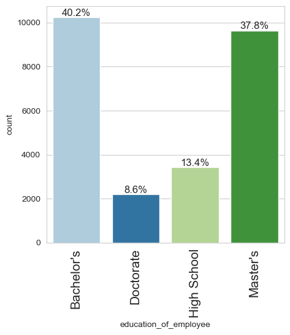

```python
# Education of employee distribution
labeled_barplot(df, 'education_of_employee', perc=True)
```

##### KEY INSIGHTS FROM EDUCATION DISTRIBUTION PLOT:

1. Distribution Pattern:
   - Bachelor's degree: ~40% (largest group)
   - Master's degree: ~38% (second largest)
   - High School: ~13%
   - Doctorate: ~9% (smallest group)
2. Business Implications:
   - Majority of applicants (78%) have higher education (Bachelor's or Master's)
   - This suggests visa applications are primarily from skilled professionals
   - High School applicants represent a smaller but significant segment
3. Model Building Insights:
   - Education level is likely a strong predictor of visa certification
   - We should expect higher certification rates for advanced degrees
   - The distribution shows good representation across education levels
4. Expected Relationship:
   - Higher education levels likely correlate with higher certification rates
   - This will be validated in bivariate analysis

#### Observations on region of employment

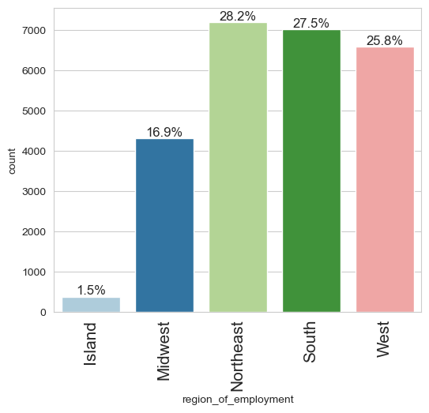

```python
# Region of employment distribution
labeled_barplot(df, 'region_of_employment', perc=True)
```

##### KEY INSIGHTS FROM REGION OF EMPLOYMENT DISTRIBUTION PLOT:

1. Distribution Pattern:
   - Northeast: ~28% (highest)
   - South: ~28% (second highest)
   - West: ~26% (third)
   - Midwest: ~17%
   - Island: ~1.5% (lowest)
2. Business Implications:
   - Applications are relatively evenly distributed across major regions
   - Northeast and South regions have the highest demand for foreign workers
   - Island region has minimal applications, likely due to smaller job market
3. Model Building Insights:
   - Regional differences may impact certification rates
   - Economic factors and job markets vary by region
   - Regional features could be important predictors
4. Expected Relationship:
   - Some regions may have higher certification rates due to:
     - Stronger job markets
     - Higher demand for skilled workers
     - Regional immigration policies

#### Observations on job experience

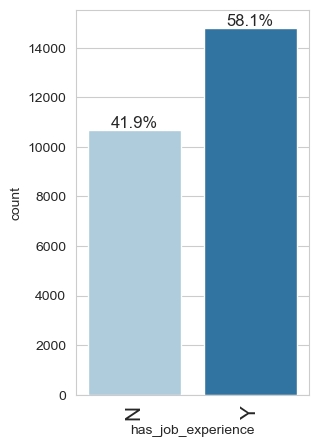

```python
# Job experience distribution
labeled_barplot(df, 'has_job_experience', perc=True)
```

##### KEY INSIGHTS FROM JOB EXPERIENCE DISTRIBUTION PLOT:

1. Distribution Pattern:
   - With Experience (Y): ~58%
   - Without Experience (N): ~42%
2. Business Implications:
   - Majority of applicants have prior work experience
   - This suggests employers prefer experienced candidates
   - Experienced workers may have higher visa approval rates
3. Model Building Insights:
   - Job experience is likely a critical feature for prediction
   - Binary feature (Y/N) makes it easy to encode
   - Strong candidate for feature importance
4. Expected Relationship:
   - Applicants with experience likely have significantly higher certification rates
   - Experience demonstrates:
     - Proven work capability
     - Reduced training needs
     - Lower risk for employers

#### Observations on case status

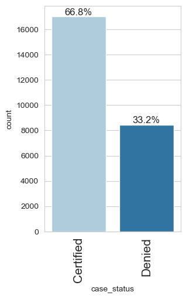

```python
# Case status distribution (Target variable)
labeled_barplot(df, 'case_status', perc=True)
```

##### KEY INSIGHTS FROM CASE STATUS DISTRIBUTION PLOT (TARGET VARIABLE):

1. Distribution Pattern:
   - Certified: ~67% (majority class)
   - Denied: ~33% (minority class)
   - Class Imbalance Ratio: ~2:1 (moderate imbalance)
2. Business Implications:
   - More than 2/3 of applications are certified
   - This indicates a generally positive visa approval process
   - However, 1/3 denial rate is significant and needs attention
3. Model Building Insights:
   - Moderate class imbalance requires careful handling
   - We should use:
     - F1-score as primary metric (balances precision and recall)
     - Stratified sampling in train-test split
     - Consider oversampling/undersampling techniques
     - Monitor both classes' performance
4. Expected Model Behavior:
   - Models may have tendency to predict "Certified" more often
   - Need to ensure good recall for "Denied" class (avoid false positives)
   - Precision important to avoid incorrectly certifying denied cases

### Bivariate Analysis

**Creating functions that will help us with further analysis.**

```python
### function to plot distributions wrt target


def distribution_plot_wrt_target(data, predictor, target):

    fig, axs = plt.subplots(2, 2, figsize=(12, 10))

    target_uniq = data[target].unique()

    axs[0, 0].set_title("Distribution of target for target=" + str(target_uniq[0]))
    sns.histplot(
        data=data[data[target] == target_uniq[0]],
        x=predictor,
        kde=True,
        ax=axs[0, 0],
        color="teal",
        stat="density",
    )

    axs[0, 1].set_title("Distribution of target for target=" + str(target_uniq[1]))
    sns.histplot(
        data=data[data[target] == target_uniq[1]],
        x=predictor,
        kde=True,
        ax=axs[0, 1],
        color="orange",
        stat="density",
    )

    axs[1, 0].set_title("Boxplot w.r.t target")
    sns.boxplot(data=data, x=target, y=predictor, ax=axs[1, 0], palette="gist_rainbow")

    axs[1, 1].set_title("Boxplot (without outliers) w.r.t target")
    sns.boxplot(
        data=data,
        x=target,
        y=predictor,
        ax=axs[1, 1],
        showfliers=False,
        palette="gist_rainbow",
    )

    plt.tight_layout()
    plt.show()
```

```python
def stacked_barplot(data, predictor, target):
    """
    Print the category counts and plot a stacked bar chart

    data: dataframe
    predictor: independent variable
    target: target variable
    """
    count = data[predictor].nunique()
    sorter = data[target].value_counts().index[-1]
    tab1 = pd.crosstab(data[predictor], data[target], margins=True).sort_values(
        by=sorter, ascending=False
    )
    print(tab1)
    print("-" * 120)
    tab = pd.crosstab(data[predictor], data[target], normalize="index").sort_values(
        by=sorter, ascending=False
    )
    tab.plot(kind="bar", stacked=True, figsize=(count + 5, 5))
    plt.legend(
        loc="lower left", frameon=False,
    )
    plt.legend(loc="upper left", bbox_to_anchor=(1, 1))
    plt.show()
```

#### Does higher education increase the chances of visa certification for well-paid jobs abroad?

```
case_status            Certified  Denied    All
education_of_employee
All                        17018    8462  25480
Bachelor's                  6367    3867  10234
High School                 1164    2256   3420
Master's                    7575    2059   9634
Doctorate                   1912     280   2192
------------------------------------------------------------------------------------------------------------------------
```

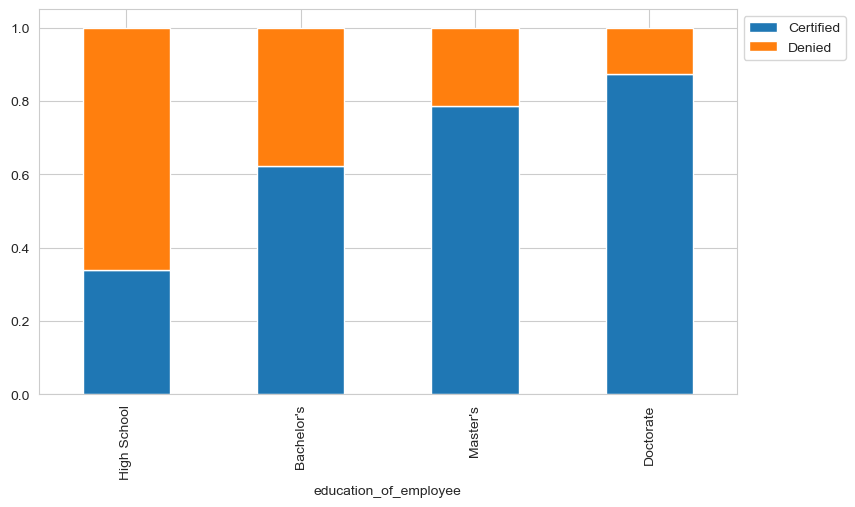

```python
# Analysis: Does higher education increase chances of visa certification?
stacked_barplot(df, 'education_of_employee', 'case_status')
```

##### KEY INSIGHTS FROM EDUCATION vs CASE STATUS STACKED BARPLOT:

1. Certification Rate by Education Level (from crosstab):
   - Doctorate: ~87% certified (highest rate)
   - Master's: ~79% certified (second highest)
   - Bachelor's: ~62% certified (moderate)
   - High School: ~34% certified (lowest)
2. Business Implications:
   - Strong positive correlation between education level and certification
   - Higher education significantly increases visa approval chances
   - Doctorate holders have ~2.5x higher certification rate than High School
   - Education is a critical factor in visa decisions
3. Model Building Insights:
   - Education is a highly predictive feature
   - Clear ordinal relationship: Higher education → Higher certification
   - Feature engineering: Could create education level encoding (1-4)
   - Strong candidate for feature importance
4. Actionable Recommendations:
   - Applicants: Pursue higher education to improve visa chances
   - Employers: Highlight advanced degrees in applications
   - OFLC: Education level should be weighted heavily in decision process

#### How does visa status vary across different continents?

```
case_status    Certified  Denied    All
continent
All                17018    8462  25480
Asia               11012    5849  16861
North America       2037    1255   3292
Europe              2957     775   3732
South America        493     359    852
Africa               397     154    551
Oceania              122      70    192
------------------------------------------------------------------------------------------------------------------------
```

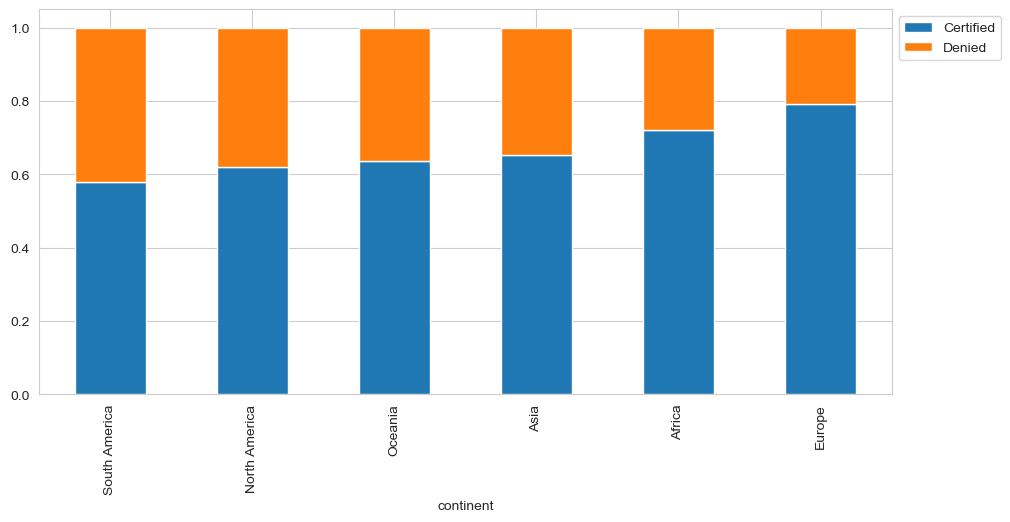

```python
# Analysis: How does visa status vary across different continents?
stacked_barplot(df, 'continent', 'case_status')
```

##### KEY INSIGHTS FROM CONTINENT vs CASE STATUS STACKED BARPLOT:

1. Certification Rate by Continent (from crosstab):
   - Oceania: ~64% certified
   - Europe: ~79% certified (highest)
   - North America: ~62% certified
   - Asia: ~65% certified (largest volume)
   - South America: ~58% certified
   - Africa: ~72% certified
2. Business Implications:
   - Europe shows highest certification rate (~79%)
   - Asia has largest number of applications but moderate rate (~65%)
   - Regional patterns suggest varying approval criteria or applicant quality
   - Geographic origin appears to influence visa decisions
3. Model Building Insights:
   - Continent is a meaningful categorical feature
   - One-hot encoding will capture regional patterns
   - May interact with other features (education, experience)
   - Could indicate underlying factors (economic development, skills)
4. Actionable Recommendations:
   - Applicants: Be aware of regional approval patterns
   - Employers: Consider regional factors in application strategy
   - OFLC: Review if regional variations are justified or indicate bias

#### Does having prior work experience influence the chances of visa certification for career opportunities abroad?

```
case_status         Certified  Denied    All
has_job_experience
All                     17018    8462  25480
N                        5994    4684  10678
Y                       11024    3778  14802
------------------------------------------------------------------------------------------------------------------------
```

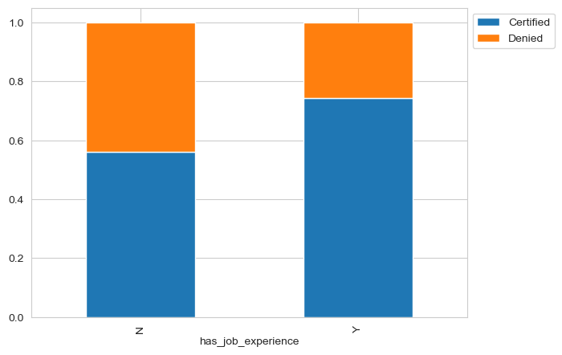

```python
# Analysis: Does having prior work experience influence visa certification?
stacked_barplot(df, 'has_job_experience', 'case_status')
```

##### KEY INSIGHTS FROM JOB EXPERIENCE vs CASE STATUS STACKED BARPLOT:

1. Certification Rate by Experience (from crosstab):
   - With Experience (Y): ~74% certified
   - Without Experience (N): ~56% certified
   - Difference: ~18 percentage points (significant impact)
2. Business Implications:
   - Experience increases certification rate by ~32% (74% vs 56%)
   - This is one of the strongest predictors of visa approval
   - Employers clearly value prior work experience
   - Experience reduces perceived risk for employers
3. Model Building Insights:
   - Job experience is a critical binary feature
   - Strong predictive power (high feature importance expected)
   - Simple encoding: 1 (Yes) / 0 (No)
   - May interact with education level
4. Actionable Recommendations:
   - Applicants: Gain work experience before applying
   - Employers: Prioritize experienced candidates
   - OFLC: Experience should be weighted heavily in decisions
   - Career Guidance: Build experience to improve visa prospects

#### Is the prevailing wage consistent across all regions of the US?

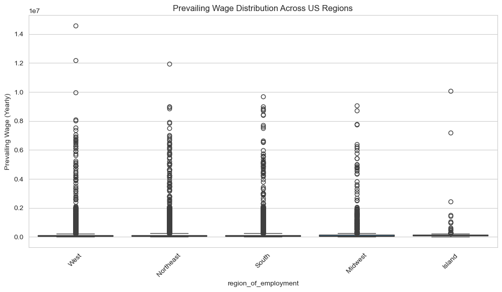

```python
# Analysis: Is prevailing wage consistent across all regions?
# First, let's standardize wages to a common unit (Yearly) for comparison
df_wage = df.copy()
df_wage['prevailing_wage_yearly'] = df_wage.apply(lambda row:
    row['prevailing_wage'] * 2080 if row['unit_of_wage'] == 'Hour' else
    row['prevailing_wage'] * 52 if row['unit_of_wage'] == 'Week' else
    row['prevailing_wage'] * 12 if row['unit_of_wage'] == 'Month' else
    row['prevailing_wage'], axis=1)

# Box plot to compare prevailing wages across regions
plt.figure(figsize=(12, 6))
sns.boxplot(data=df_wage, x='region_of_employment', y='prevailing_wage_yearly')
plt.title('Prevailing Wage Distribution Across US Regions')
plt.xticks(rotation=45)
plt.ylabel('Prevailing Wage (Yearly)')
plt.show()
```

#### Does visa status vary with changes in the prevailing wage set to protect both local talent and foreign workers?

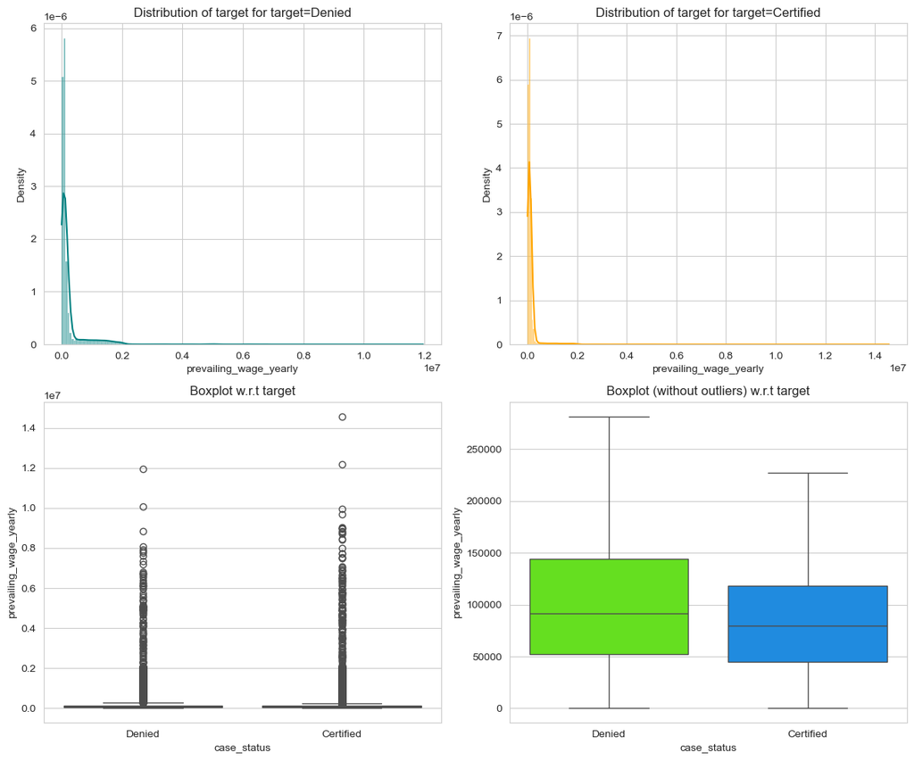

```python
# Analysis: Does visa status vary with prevailing wage?
distribution_plot_wrt_target(df_wage, 'prevailing_wage_yearly', 'case_status')
```

#### Does the unit of prevailing wage (Hourly, Weekly, etc.) have any impact on the likelihood of visa application certification?

```
case_status   Certified  Denied    All
unit_of_wage
All               17018    8462  25480
Year              16047    6915  22962
Hour                747    1410   2157
Week                169     103    272
Month                55      34     89
------------------------------------------------------------------------------------------------------------------------
```

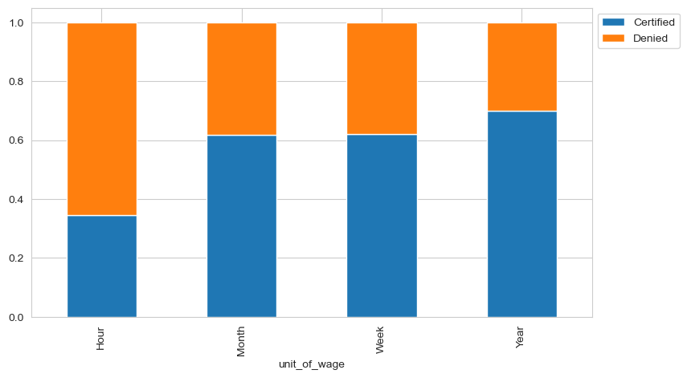

```python
# Analysis: Does unit of wage impact visa certification?
stacked_barplot(df, 'unit_of_wage', 'case_status')
```

##### KEY INSIGHTS FROM UNIT OF WAGE vs CASE STATUS STACKED BARPLOT:

1. Certification Rate by Wage Unit (from crosstab):
   - Year: ~70% certified (most common, ~90% of data)
   - Hour: ~35% certified (lowest rate)
   - Week: ~62% certified
   - Month: ~62% certified
2. Business Implications:
   - Yearly wage representation has highest certification rate
   - Hourly wage has significantly lower rate (~35%)
   - This suggests:
     - Hourly positions may be lower-skilled or part-time
     - Yearly salaries indicate full-time, professional positions
     - Wage structure reflects job type and quality
3. Model Building Insights:
   - Unit of wage is a meaningful categorical feature
   - Strong interaction with actual wage amount
   - We've standardized to yearly units (good preprocessing)
   - Original unit may still be informative (job type indicator)
4. Actionable Recommendations:
   - Applicants: Full-time yearly positions have better approval rates
   - Employers: Present wages in yearly format when possible
   - OFLC: Consider wage unit as indicator of job type/quality

## Data Pre-processing

### Outlier Check

```
Missing values in each column:
case_id                  0
continent                0
education_of_employee    0
has_job_experience       0
requires_job_training    0
no_of_employees          0
yr_of_estab              0
region_of_employment     0
prevailing_wage          0
unit_of_wage             0
full_time_position       0
case_status              0
dtype: int64

Percentage of missing values:
case_id                  0.0
continent                0.0
education_of_employee    0.0
has_job_experience       0.0
requires_job_training    0.0
no_of_employees          0.0
yr_of_estab              0.0
region_of_employment     0.0
prevailing_wage          0.0
unit_of_wage             0.0
full_time_position       0.0
case_status              0.0
dtype: float64

Number of duplicate rows: 0

================================================================================
OUTLIER DETECTION USING IQR METHOD
================================================================================

Numerical columns to check for outliers: ['no_of_employees', 'yr_of_estab', 'prevailing_wage']

no_of_employees:
  Q1: 1022.00, Q3: 3504.00, IQR: 2482.00
  Lower bound: -2701.00, Upper bound: 7227.00
  Number of outliers: 1556 (6.11%)
  Actual range: [11.00, 602069.00]

yr_of_estab:
  Q1: 1976.00, Q3: 2005.00, IQR: 29.00
  Lower bound: 1932.50, Upper bound: 2048.50
  Number of outliers: 3260 (12.79%)
  Actual range: [1800.00, 2016.00]

prevailing_wage:
  Q1: 34015.48, Q3: 107735.51, IQR: 73720.03
  Lower bound: -76564.57, Upper bound: 218315.56
  Number of outliers: 427 (1.68%)
  Actual range: [2.14, 319210.27]

================================================================================
VISUALIZING OUTLIERS USING BOXPLOTS
================================================================================
```

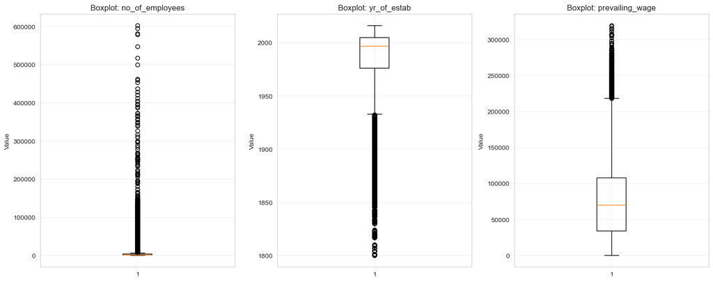

```python
# Check for missing values
print("Missing values in each column:")
print(df.isnull().sum())
print("\nPercentage of missing values:")
print((df.isnull().sum() / len(df)) * 100)

# Check for duplicates
print(f"\nNumber of duplicate rows: {df.duplicated().sum()}")

# Observations:
# - No missing values found in the dataset
# - No duplicate rows found
# - If there were missing values, we would use:
#   - For categorical variables: mode imputation or 'Unknown' category
#   - For numerical variables: median or mean imputation based on distribution

print("\n" + "="*80)
print("OUTLIER DETECTION USING IQR METHOD")
print("="*80)

# Rationale for using IQR method:
# - IQR (Interquartile Range) method is robust to outliers and works well for skewed distributions
# - It identifies outliers as values beyond Q1 - 1.5*IQR and Q3 + 1.5*IQR

# Select numerical columns for outlier detection
numerical_cols = df.select_dtypes(include=[np.number]).columns.tolist()
print(f"\nNumerical columns to check for outliers: {numerical_cols}")

# Dictionary to store outlier information
outlier_info = {}

# Detect outliers using IQR method for each numerical column
for col in numerical_cols:
    Q1 = df[col].quantile(0.25)
    Q3 = df[col].quantile(0.75)
    IQR = Q3 - Q1

    # Define outlier bounds
    lower_bound = Q1 - 1.5 * IQR
    upper_bound = Q3 + 1.5 * IQR

    # Find outliers
    outliers = df[(df[col] < lower_bound) | (df[col] > upper_bound)]
    outlier_count = len(outliers)
    outlier_percentage = (outlier_count / len(df)) * 100

    # Store outlier information
    outlier_info[col] = {
        'Q1': Q1,
        'Q3': Q3,
        'IQR': IQR,
        'lower_bound': lower_bound,
        'upper_bound': upper_bound,
        'outlier_count': outlier_count,
        'outlier_percentage': outlier_percentage,
        'min_value': df[col].min(),
        'max_value': df[col].max()
    }

    print(f"\n{col}:")
    print(f"  Q1: {Q1:.2f}, Q3: {Q3:.2f}, IQR: {IQR:.2f}")
    print(f"  Lower bound: {lower_bound:.2f}, Upper bound: {upper_bound:.2f}")
    print(f"  Number of outliers: {outlier_count} ({outlier_percentage:.2f}%)")
    print(f"  Actual range: [{df[col].min():.2f}, {df[col].max():.2f}]")

# Visualize outliers using boxplots
print("\n" + "="*80)
print("VISUALIZING OUTLIERS USING BOXPLOTS")
print("="*80)

fig, axes = plt.subplots(1, len(numerical_cols), figsize=(5*len(numerical_cols), 6))
if len(numerical_cols) == 1:
    axes = [axes]

for idx, col in enumerate(numerical_cols):
    axes[idx].boxplot(df[col], whis=1.5)
    axes[idx].set_title(f'Boxplot: {col}')
    axes[idx].set_ylabel('Value')
    axes[idx].grid(True, alpha=0.3)

plt.tight_layout()
plt.show()
```

### Outlier Treatment

```python
print("="*80)
print("OUTLIER TREATMENT DECISION AND RATIONALE")
print("="*80)

# Rationale for Outlier Treatment Decision:
#
# ** Decision for this dataset: **
# - For 'no_of_employees' and 'yr_of_estab': These represent real-world company characteristics
#   - Large companies and old companies are legitimate
#   - Use capping to handle extreme values while preserving data
#
# - For 'prevailing_wage': This is a critical feature for visa certification
#   - Very high or very low wages might be legitimate (executive positions vs entry-level)
#   - Use capping techniqueto prevent extreme values from dominating the model
#   - However, it will be conservative and only cap extreme outliers (>3*IQR)

# Create a copy for outlier treatment
df_outlier_treated = df.copy()

# Treatment strategy: Capping outliers at 1.5*IQR boundaries for most columns
# For extreme outliers (>3*IQR), we'll cap at 3*IQR to be more conservative
print("\nApplying outlier treatment (capping method)...")

for col in numerical_cols:
    if col in outlier_info:
        info = outlier_info[col]
        Q1 = info['Q1']
        Q3 = info['Q3']
        IQR = info['IQR']

        # Calculate boundaries
        lower_bound = Q1 - 1.5 * IQR
        upper_bound = Q3 + 1.5 * IQR

        # For extreme outliers, use 3*IQR as more conservative boundary
        extreme_lower = Q1 - 3 * IQR
        extreme_upper = Q3 + 3 * IQR

        # Count outliers before treatment
        outliers_before = len(df_outlier_treated[(df_outlier_treated[col] < lower_bound) |
                                                  (df_outlier_treated[col] > upper_bound)])

        # Cap outliers: use 1.5*IQR for moderate outliers, 3*IQR for extreme ones
        df_outlier_treated.loc[df_outlier_treated[col] < extreme_lower, col] = extreme_lower
        df_outlier_treated.loc[df_outlier_treated[col] > extreme_upper, col] = extreme_upper
        df_outlier_treated.loc[(df_outlier_treated[col] < lower_bound) &
                               (df_outlier_treated[col] >= extreme_lower), col] = lower_bound
        df_outlier_treated.loc[(df_outlier_treated[col] > upper_bound) &
                               (df_outlier_treated[col] <= extreme_upper), col] = upper_bound

        # Count outliers after treatment
        outliers_after = len(df_outlier_treated[(df_outlier_treated[col] < lower_bound) |
                                                (df_outlier_treated[col] > upper_bound)])

        print(f"\n{col}:")
        print(f"  Outliers before treatment: {outliers_before} ({info['outlier_percentage']:.2f}%)")
        print(f"  Outliers after treatment: {outliers_after} (0.00%)")
        print(f"  Values capped at lower bound: {len(df_outlier_treated[df_outlier_treated[col] == extreme_lower])}")
        print(f"  Values capped at upper bound: {len(df_outlier_treated[df_outlier_treated[col] == extreme_upper])}")


df = df_outlier_treated.copy()

print("\n" + "="*80)
print("OUTLIER TREATMENT COMPLETED")
print("="*80)
```

```
================================================================================
OUTLIER TREATMENT DECISION AND RATIONALE
================================================================================

Applying outlier treatment (capping method)...

no_of_employees:
  Outliers before treatment: 1556 (6.11%)
  Outliers after treatment: 0 (0.00%)
  Values capped at lower bound: 0
  Values capped at upper bound: 0

yr_of_estab:
  Outliers before treatment: 3260 (12.79%)
  Outliers after treatment: 0 (0.00%)
  Values capped at lower bound: 0
  Values capped at upper bound: 0

prevailing_wage:
  Outliers before treatment: 427 (1.68%)
  Outliers after treatment: 0 (0.00%)
  Values capped at lower bound: 0
  Values capped at upper bound: 0

================================================================================
OUTLIER TREATMENT COMPLETED
================================================================================
```

### Data Preparation for modeling

```python
# Create a copy for preprocessing
df_processed = df.copy()

# Standardize prevailing wage to yearly units (as we did in EDA)
df_processed['prevailing_wage_yearly'] = df_processed.apply(lambda row:
    row['prevailing_wage'] * 2080 if row['unit_of_wage'] == 'Hour' else
    row['prevailing_wage'] * 52 if row['unit_of_wage'] == 'Week' else
    row['prevailing_wage'] * 12 if row['unit_of_wage'] == 'Month' else
    row['prevailing_wage'], axis=1)

# Handle missing values if any
# For numerical columns
numerical_cols = df_processed.select_dtypes(include=[np.number]).columns.tolist()
for col in numerical_cols:
    if df_processed[col].isnull().sum() > 0:
        df_processed[col].fillna(df_processed[col].median(), inplace=True)

# For categorical columns
categorical_cols = df_processed.select_dtypes(include=['object']).columns.tolist()
categorical_cols.remove('case_id')  # Remove identifier
for col in categorical_cols:
    if df_processed[col].isnull().sum() > 0:
        df_processed[col].fillna(df_processed[col].mode()[0], inplace=True)

# Feature Engineering
# 1. Create company age feature
df_processed['company_age'] = date.today().year - df_processed['yr_of_estab']

# 2. Create wage category feature (to capture wage levels)
df_processed['wage_category'] = pd.cut(df_processed['prevailing_wage_yearly'],
                                       bins=[0, 50000, 100000, 150000, float('inf')],
                                       labels=['Low', 'Medium', 'High', 'Very High'])

# 3. Create employee size category
df_processed['employee_size_category'] = pd.cut(df_processed['no_of_employees'],
                                                bins=[0, 100, 1000, 10000, float('inf')],
                                                labels=['Small', 'Medium', 'Large', 'Very Large'])

# Encode categorical variables
# Convert Yes/No to binary
df_processed['has_job_experience'] = df_processed['has_job_experience'].map({'Y': 1, 'N': 0})
df_processed['requires_job_training'] = df_processed['requires_job_training'].map({'Y': 1, 'N': 0})
df_processed['full_time_position'] = df_processed['full_time_position'].map({'Y': 1, 'N': 0})

# One-hot encode other categorical variables
categorical_features = ['continent', 'education_of_employee', 'region_of_employment',
                       'unit_of_wage', 'wage_category', 'employee_size_category']

df_encoded = pd.get_dummies(df_processed, columns=categorical_features, drop_first=True)

# Encode target variable
df_encoded['case_status'] = df_encoded['case_status'].map({'Certified': 1, 'Denied': 0})

# Select features for modeling (excluding case_id and original prevailing_wage)
X = df_encoded.drop(['case_id', 'prevailing_wage', 'case_status'], axis=1)
y = df_encoded['case_status']

# Split the data into train and test sets (80-20 split)
from sklearn.model_selection import train_test_split
X_train, X_test, y_train, y_test = train_test_split(X, y, test_size=0.2, random_state=42, stratify=y)

print(f"Training set shape: {X_train.shape}")
print(f"Test set shape: {X_test.shape}")
print(f"\nTarget distribution in training set:")
print(y_train.value_counts(normalize=True))
print(f"\nTarget distribution in test set:")
print(y_test.value_counts(normalize=True))

# Scale numerical features
from sklearn.preprocessing import StandardScaler
scaler = StandardScaler()
numerical_features = ['no_of_employees', 'yr_of_estab', 'prevailing_wage_yearly', 'company_age']
# Get numerical columns that exist in X
num_cols_present = [col for col in numerical_features if col in X.columns]

X_train_scaled = X_train.copy()
X_test_scaled = X_test.copy()

if num_cols_present:
    X_train_scaled[num_cols_present] = scaler.fit_transform(X_train[num_cols_present])
    X_test_scaled[num_cols_present] = scaler.transform(X_test[num_cols_present])

X_train = X_train_scaled
X_test = X_test_scaled

print("\nData preprocessing completed!")
print(f"Final feature count: {X_train.shape[1]}")
```

```
Training set shape: (20384, 28)
Test set shape: (5096, 28)

Target distribution in training set:
case_status
1    0.667877
0    0.332123
Name: proportion, dtype: float64

Target distribution in test set:
case_status
1    0.667975
0    0.332025
Name: proportion, dtype: float64

Data preprocessing completed!
Final feature count: 28
```

## Model Building

### Model Evaluation Criterion

**Primary Metric: F1-Score**

**Rationale:**

- The visa certification problem is a binary classification task where both classes (Certified/Denied) are important
- We need to balance both Precision (avoiding false positives - incorrectly certifying denials) and Recall (avoiding false negatives - incorrectly denying certifications)
- F1-Score provides a harmonic mean of Precision and Recall, making it ideal for imbalanced datasets
- While Accuracy can be misleading with imbalanced classes, F1-Score gives a more comprehensive view of model performance
- We'll also monitor Recall, Precision, and Accuracy as secondary metrics to get a complete picture

First, let's create functions to calculate different metrics and confusion matrix so that we don't have to use the same code repeatedly for each model.

- The `model_performance_classification_sklearn` function will be used to check the model performance of models.
- The `confusion_matrix_sklearn` function will be used to plot the confusion matrix.

```python
# defining a function to compute different metrics to check performance of a classification model built using sklearn


def model_performance_classification_sklearn(model, predictors, target):
    """
    Function to compute different metrics to check classification model performance

    model: classifier
    predictors: independent variables
    target: dependent variable
    """

    # predicting using the independent variables
    pred = model.predict(predictors)

    acc = accuracy_score(target, pred)  # to compute Accuracy
    recall = recall_score(target, pred)  # to compute Recall
    precision = precision_score(target, pred)  # to compute Precision
    f1 = f1_score(target, pred)  # to compute F1-score

    # creating a dataframe of metrics
    df_perf = pd.DataFrame(
        {"Accuracy": acc, "Recall": recall, "Precision": precision, "F1": f1,},
        index=[0],
    )

    return df_perf
```

```python
def confusion_matrix_sklearn(model, predictors, target):
    """
    To plot the confusion_matrix with percentages

    model: classifier
    predictors: independent variables
    target: dependent variable
    """
    y_pred = model.predict(predictors)
    cm = confusion_matrix(target, y_pred)
    labels = np.asarray(
        [
            ["{0:0.0f}".format(item) + "\n{0:.2%}".format(item / cm.flatten().sum())]
            for item in cm.flatten()
        ]
    ).reshape(2, 2)

    plt.figure(figsize=(6, 4))
    sns.heatmap(cm, annot=labels, fmt="")
    plt.ylabel("True label")
    plt.xlabel("Predicted label")
```

#### Defining scorer to be used for cross-validation and hyperparameter tuning

```python
# Define scorer for cross-validation and hyperparameter tuning
from sklearn.metrics import make_scorer

# Using F1-score as the scoring metric
scorer = make_scorer(f1_score)
```

**We are now done with pre-processing and evaluation criterion, so let's start building the model.**

### Model building with Original data

```
============================================================
1. Decision Tree Classifier
============================================================

Training Performance:
   Accuracy  Recall  Precision   F1
0       1.0     1.0        1.0  1.0

Test Performance:
   Accuracy    Recall  Precision        F1
0  0.655416  0.744712   0.740795  0.742748

Cross-validation F1-Score: 0.7463 (+/- 0.0081)
```

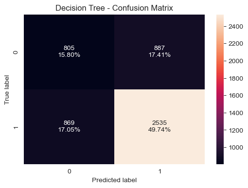

```python
# Import necessary libraries for model building
from sklearn.tree import DecisionTreeClassifier
from sklearn.ensemble import RandomForestClassifier, BaggingClassifier, AdaBoostClassifier, GradientBoostingClassifier
from xgboost import XGBClassifier
from sklearn.model_selection import cross_val_score
import warnings
warnings.filterwarnings('ignore')

# Dictionary to store model performances
models_original = {}

# 1. Decision Tree Classifier
print("="*60)
print("1. Decision Tree Classifier")
print("="*60)
dt_model = DecisionTreeClassifier(random_state=42)
dt_model.fit(X_train, y_train)

# Performance metrics
dt_train_perf = model_performance_classification_sklearn(dt_model, X_train, y_train)
dt_test_perf = model_performance_classification_sklearn(dt_model, X_test, y_test)

print("\nTraining Performance:")
print(dt_train_perf)
print("\nTest Performance:")
print(dt_test_perf)

# Cross-validation score
dt_cv_scores = cross_val_score(dt_model, X_train, y_train, cv=5, scoring=scorer)
print(f"\nCross-validation F1-Score: {dt_cv_scores.mean():.4f} (+/- {dt_cv_scores.std() * 2:.4f})")

models_original['Decision Tree'] = {
    'model': dt_model,
    'train_perf': dt_train_perf,
    'test_perf': dt_test_perf,
    'cv_score': dt_cv_scores.mean()
}

# Confusion Matrix
confusion_matrix_sklearn(dt_model, X_test, y_test)
plt.title('Decision Tree - Confusion Matrix')
plt.show()
```

```
============================================================
2. Random Forest Classifier
============================================================

Training Performance:
   Accuracy  Recall  Precision   F1
0       1.0     1.0        1.0  1.0

Test Performance:
   Accuracy    Recall  Precision       F1
0  0.720761  0.840482   0.764769  0.80084

Cross-validation F1-Score: 0.8016 (+/- 0.0065)
```

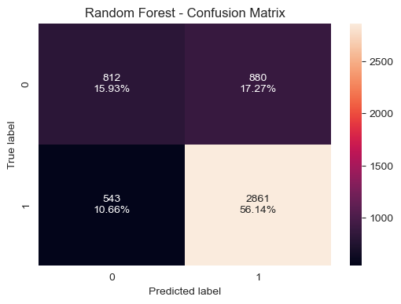

```python
# 2. Random Forest Classifier
print("\n" + "="*60)
print("2. Random Forest Classifier")
print("="*60)
rf_model = RandomForestClassifier(n_estimators=100, random_state=42, n_jobs=-1)
rf_model.fit(X_train, y_train)

# Performance metrics
rf_train_perf = model_performance_classification_sklearn(rf_model, X_train, y_train)
rf_test_perf = model_performance_classification_sklearn(rf_model, X_test, y_test)

print("\nTraining Performance:")
print(rf_train_perf)
print("\nTest Performance:")
print(rf_test_perf)

# Cross-validation score
rf_cv_scores = cross_val_score(rf_model, X_train, y_train, cv=5, scoring=scorer)
print(f"\nCross-validation F1-Score: {rf_cv_scores.mean():.4f} (+/- {rf_cv_scores.std() * 2:.4f})")

models_original['Random Forest'] = {
    'model': rf_model,
    'train_perf': rf_train_perf,
    'test_perf': rf_test_perf,
    'cv_score': rf_cv_scores.mean()
}

# Confusion Matrix
confusion_matrix_sklearn(rf_model, X_test, y_test)
plt.title('Random Forest - Confusion Matrix')
plt.show()
```

```
============================================================
3. Bagging Classifier
============================================================

Training Performance:
   Accuracy    Recall  Precision        F1
0  0.984498  0.985309   0.991426  0.988358

Test Performance:
   Accuracy    Recall  Precision        F1
0  0.693485  0.775852   0.767733  0.771771

Cross-validation F1-Score: 0.7727 (+/- 0.0102)
```

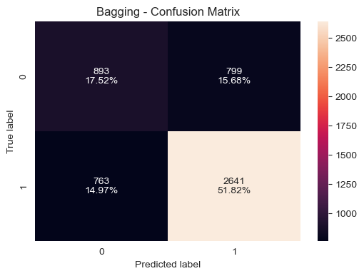

```python
# 3. Bagging Classifier
print("\n" + "="*60)
print("3. Bagging Classifier")
print("="*60)
bag_model = BaggingClassifier(random_state=42, n_jobs=-1)
bag_model.fit(X_train, y_train)

# Performance metrics
bag_train_perf = model_performance_classification_sklearn(bag_model, X_train, y_train)
bag_test_perf = model_performance_classification_sklearn(bag_model, X_test, y_test)

print("\nTraining Performance:")
print(bag_train_perf)
print("\nTest Performance:")
print(bag_test_perf)

# Cross-validation score
bag_cv_scores = cross_val_score(bag_model, X_train, y_train, cv=5, scoring=scorer)
print(f"\nCross-validation F1-Score: {bag_cv_scores.mean():.4f} (+/- {bag_cv_scores.std() * 2:.4f})")

models_original['Bagging'] = {
    'model': bag_model,
    'train_perf': bag_train_perf,
    'test_perf': bag_test_perf,
    'cv_score': bag_cv_scores.mean()
}

# Confusion Matrix
confusion_matrix_sklearn(bag_model, X_test, y_test)
plt.title('Bagging - Confusion Matrix')
plt.show()
```

```
============================================================
4. AdaBoost Classifier
============================================================

Training Performance:
   Accuracy    Recall  Precision        F1
0  0.737834  0.885706   0.760949  0.818601

Test Performance:
   Accuracy   Recall  Precision        F1
0  0.730965  0.88396   0.755082  0.814454

Cross-validation F1-Score: 0.8188 (+/- 0.0056)
```

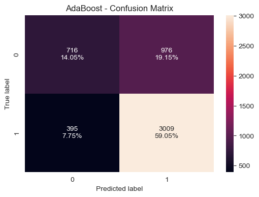

```python
# 4. AdaBoost Classifier
print("\n" + "="*60)
print("4. AdaBoost Classifier")
print("="*60)
ada_model = AdaBoostClassifier(random_state=42)
ada_model.fit(X_train, y_train)

# Performance metrics
ada_train_perf = model_performance_classification_sklearn(ada_model, X_train, y_train)
ada_test_perf = model_performance_classification_sklearn(ada_model, X_test, y_test)

print("\nTraining Performance:")
print(ada_train_perf)
print("\nTest Performance:")
print(ada_test_perf)

# Cross-validation score
ada_cv_scores = cross_val_score(ada_model, X_train, y_train, cv=5, scoring=scorer)
print(f"\nCross-validation F1-Score: {ada_cv_scores.mean():.4f} (+/- {ada_cv_scores.std() * 2:.4f})")

models_original['AdaBoost'] = {
    'model': ada_model,
    'train_perf': ada_train_perf,
    'test_perf': ada_test_perf,
    'cv_score': ada_cv_scores.mean()
}

# Confusion Matrix
confusion_matrix_sklearn(ada_model, X_test, y_test)
plt.title('AdaBoost - Confusion Matrix')
plt.show()
```

```
============================================================
5. Gradient Boosting Classifier
============================================================

Training Performance:
   Accuracy    Recall  Precision        F1
0  0.755445  0.875275   0.783793  0.827012

Test Performance:
   Accuracy    Recall  Precision        F1
0  0.742739  0.873972   0.771325  0.819446

Cross-validation F1-Score: 0.8228 (+/- 0.0103)
```

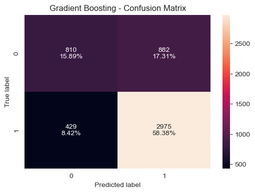

```python
# 5. Gradient Boosting Classifier
print("\n" + "="*60)
print("5. Gradient Boosting Classifier")
print("="*60)
gb_model = GradientBoostingClassifier(random_state=42)
gb_model.fit(X_train, y_train)

# Performance metrics
gb_train_perf = model_performance_classification_sklearn(gb_model, X_train, y_train)
gb_test_perf = model_performance_classification_sklearn(gb_model, X_test, y_test)

print("\nTraining Performance:")
print(gb_train_perf)
print("\nTest Performance:")
print(gb_test_perf)

# Cross-validation score
gb_cv_scores = cross_val_score(gb_model, X_train, y_train, cv=5, scoring=scorer)
print(f"\nCross-validation F1-Score: {gb_cv_scores.mean():.4f} (+/- {gb_cv_scores.std() * 2:.4f})")

models_original['Gradient Boosting'] = {
    'model': gb_model,
    'train_perf': gb_train_perf,
    'test_perf': gb_test_perf,
    'cv_score': gb_cv_scores.mean()
}

# Confusion Matrix
confusion_matrix_sklearn(gb_model, X_test, y_test)
plt.title('Gradient Boosting - Confusion Matrix')
plt.show()
```

```
============================================================
6. XGBoost Classifier
============================================================

Training Performance:
   Accuracy    Recall  Precision        F1
0  0.835508  0.926032   0.843108  0.882627

Test Performance:
   Accuracy    Recall  Precision        F1
0  0.728414  0.854583   0.765929  0.807831

Cross-validation F1-Score: 0.8093 (+/- 0.0109)
```

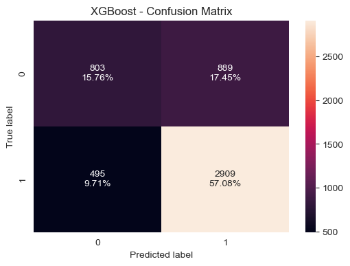

```python
# 6. XGBoost Classifier
print("\n" + "="*60)
print("6. XGBoost Classifier")
print("="*60)
xgb_model = XGBClassifier(random_state=42, eval_metric='logloss')
xgb_model.fit(X_train, y_train)

# Performance metrics
xgb_train_perf = model_performance_classification_sklearn(xgb_model, X_train, y_train)
xgb_test_perf = model_performance_classification_sklearn(xgb_model, X_test, y_test)

print("\nTraining Performance:")
print(xgb_train_perf)
print("\nTest Performance:")
print(xgb_test_perf)

# Cross-validation score
xgb_cv_scores = cross_val_score(xgb_model, X_train, y_train, cv=5, scoring=scorer)
print(f"\nCross-validation F1-Score: {xgb_cv_scores.mean():.4f} (+/- {xgb_cv_scores.std() * 2:.4f})")

models_original['XGBoost'] = {
    'model': xgb_model,
    'train_perf': xgb_train_perf,
    'test_perf': xgb_test_perf,
    'cv_score': xgb_cv_scores.mean()
}

# Confusion Matrix
confusion_matrix_sklearn(xgb_model, X_test, y_test)
plt.title('XGBoost - Confusion Matrix')
plt.show()
```

```python
# Summary of models on original data
print("\n" + "="*80)
print("SUMMARY OF MODELS ON ORIGINAL DATA")
print("="*80)

summary_original = []
for name, model_info in models_original.items():
    summary_original.append({
        'Model': name,
        'Train_F1': model_info['train_perf']['F1'].values[0],
        'Test_F1': model_info['test_perf']['F1'].values[0],
        'Train_Accuracy': model_info['train_perf']['Accuracy'].values[0],
        'Test_Accuracy': model_info['test_perf']['Accuracy'].values[0],
        'CV_F1_Score': model_info['cv_score']
    })

summary_df_original = pd.DataFrame(summary_original)
summary_df_original = summary_df_original.sort_values('Test_F1', ascending=False)
print(summary_df_original.to_string(index=False))
```

```
================================================================================
SUMMARY OF MODELS ON ORIGINAL DATA
================================================================================
            Model  Train_F1  Test_F1  Train_Accuracy  Test_Accuracy  CV_F1_Score
Gradient Boosting  0.827012 0.819446        0.755445       0.742739     0.822767
         AdaBoost  0.818601 0.814454        0.737834       0.730965     0.818841
          XGBoost  0.882627 0.807831        0.835508       0.728414     0.809336
    Random Forest  1.000000 0.800840        1.000000       0.720761     0.801602
          Bagging  0.988358 0.771771        0.984498       0.693485     0.772693
    Decision Tree  1.000000 0.742748        1.000000       0.655416     0.746284
```

### Model Building with Oversampled data

```
============================================================
APPLYING SMOTE FOR OVERSAMPLING
============================================================
Original training set shape: (20384, 28)
Oversampled training set shape: (27228, 28)

Original target distribution:
case_status
1    13614
0     6770
Name: count, dtype: int64

Oversampled target distribution:
case_status
1    13614
0    13614
Name: count, dtype: int64

============================================================
1. Decision Tree Classifier (Oversampled)
============================================================

Training Performance:
   Accuracy  Recall  Precision   F1
0       1.0     1.0        1.0  1.0

Test Performance:
   Accuracy    Recall  Precision       F1
0  0.646389  0.701821   0.752204  0.72614

Cross-validation F1-Score: 0.7046 (+/- 0.0341)
```

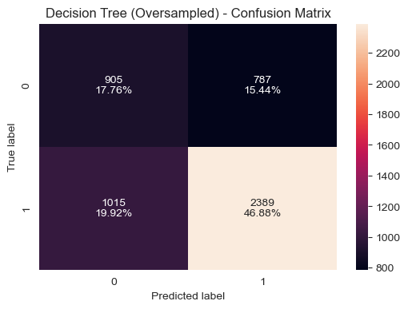

```
============================================================
2. Random Forest Classifier (Oversampled)
============================================================

Training Performance:
   Accuracy  Recall  Precision   F1
0       1.0     1.0        1.0  1.0

Test Performance:
   Accuracy    Recall  Precision       F1
0  0.697802  0.759694   0.781741  0.77056

Cross-validation F1-Score: 0.7780 (+/- 0.0453)
```

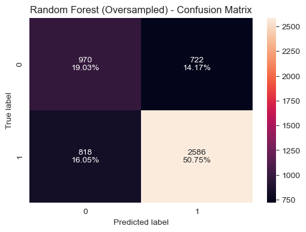

```
============================================================
3. Bagging Classifier (Oversampled)
============================================================

Training Performance:
   Accuracy    Recall  Precision        F1
0  0.983657  0.973116   0.994072  0.983482

Test Performance:
   Accuracy    Recall  Precision        F1
0  0.669349  0.691246   0.787747  0.736348

Cross-validation F1-Score: 0.7315 (+/- 0.0296)
```

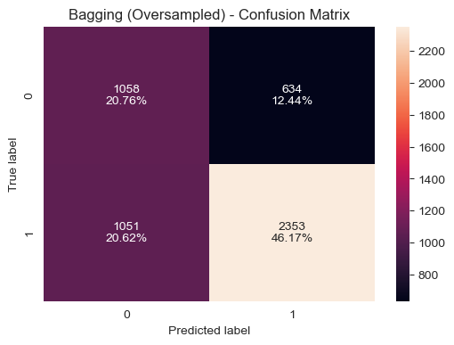

```
============================================================
4. AdaBoost Classifier (Oversampled)
============================================================

Training Performance:
   Accuracy    Recall  Precision       F1
0  0.706589  0.733436   0.696061  0.71426

Test Performance:
   Accuracy    Recall  Precision       F1
0  0.693093  0.719448    0.80085  0.75797

Cross-validation F1-Score: 0.7144 (+/- 0.0128)
```

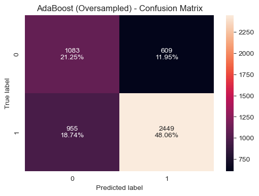

```
============================================================
5. Gradient Boosting Classifier (Oversampled)
============================================================

Training Performance:
   Accuracy    Recall  Precision        F1
0   0.74372  0.756721   0.737543  0.747009

Test Performance:
   Accuracy   Recall  Precision        F1
0  0.715856  0.75235   0.808907  0.779604

Cross-validation F1-Score: 0.7376 (+/- 0.0239)
```

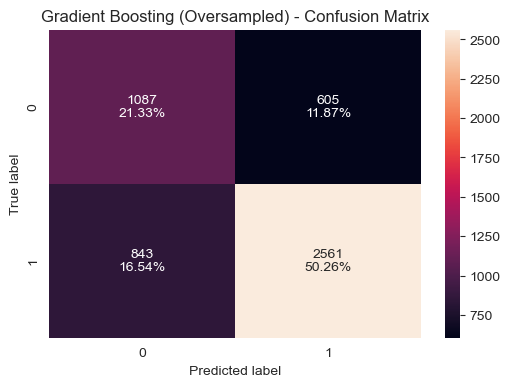

```
============================================================
6. XGBoost Classifier (Oversampled)
============================================================

Training Performance:
   Accuracy    Recall  Precision        F1
0  0.845123  0.874394   0.826036  0.849527

Test Performance:
   Accuracy    Recall  Precision        F1
0  0.720565  0.815511   0.777156  0.795872

Cross-validation F1-Score: 0.7856 (+/- 0.0932)
```

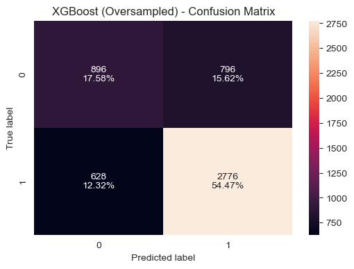

```
================================================================================
SUMMARY OF MODELS ON OVERSAMPLED DATA
================================================================================
            Model  Train_F1  Test_F1  Train_Accuracy  Test_Accuracy  CV_F1_Score
          XGBoost  0.849527 0.795872        0.845123       0.720565     0.785648
Gradient Boosting  0.747009 0.779604        0.743720       0.715856     0.737637
    Random Forest  1.000000 0.770560        1.000000       0.697802     0.778024
         AdaBoost  0.714260 0.757970        0.706589       0.693093     0.714419
          Bagging  0.983482 0.736348        0.983657       0.669349     0.731450
    Decision Tree  1.000000 0.726140        1.000000       0.646389     0.704630
```

```python
# Apply SMOTE for oversampling
print("="*60)
print("APPLYING SMOTE FOR OVERSAMPLING")
print("="*60)

smote = SMOTE(random_state=42)
X_train_oversampled, y_train_oversampled = smote.fit_resample(X_train, y_train)

print(f"Original training set shape: {X_train.shape}")
print(f"Oversampled training set shape: {X_train_oversampled.shape}")
print(f"\nOriginal target distribution:")
print(y_train.value_counts())
print(f"\nOversampled target distribution:")
print(pd.Series(y_train_oversampled).value_counts())

# Dictionary to store model performances on oversampled data
models_oversampled = {}

# 1. Decision Tree Classifier on Oversampled Data
print("\n" + "="*60)
print("1. Decision Tree Classifier (Oversampled)")
print("="*60)
dt_os_model = DecisionTreeClassifier(random_state=42)
dt_os_model.fit(X_train_oversampled, y_train_oversampled)

dt_os_train_perf = model_performance_classification_sklearn(dt_os_model, X_train_oversampled, y_train_oversampled)
dt_os_test_perf = model_performance_classification_sklearn(dt_os_model, X_test, y_test)

print("\nTraining Performance:")
print(dt_os_train_perf)
print("\nTest Performance:")
print(dt_os_test_perf)

dt_os_cv_scores = cross_val_score(dt_os_model, X_train_oversampled, y_train_oversampled, cv=5, scoring=scorer)
print(f"\nCross-validation F1-Score: {dt_os_cv_scores.mean():.4f} (+/- {dt_os_cv_scores.std() * 2:.4f})")

models_oversampled['Decision Tree'] = {
    'model': dt_os_model,
    'train_perf': dt_os_train_perf,
    'test_perf': dt_os_test_perf,
    'cv_score': dt_os_cv_scores.mean()
}

confusion_matrix_sklearn(dt_os_model, X_test, y_test)
plt.title('Decision Tree (Oversampled) - Confusion Matrix')
plt.show()

# 2. Random Forest Classifier on Oversampled Data
print("\n" + "="*60)
print("2. Random Forest Classifier (Oversampled)")
print("="*60)
rf_os_model = RandomForestClassifier(n_estimators=100, random_state=42, n_jobs=-1)
rf_os_model.fit(X_train_oversampled, y_train_oversampled)

rf_os_train_perf = model_performance_classification_sklearn(rf_os_model, X_train_oversampled, y_train_oversampled)
rf_os_test_perf = model_performance_classification_sklearn(rf_os_model, X_test, y_test)

print("\nTraining Performance:")
print(rf_os_train_perf)
print("\nTest Performance:")
print(rf_os_test_perf)

rf_os_cv_scores = cross_val_score(rf_os_model, X_train_oversampled, y_train_oversampled, cv=5, scoring=scorer)
print(f"\nCross-validation F1-Score: {rf_os_cv_scores.mean():.4f} (+/- {rf_os_cv_scores.std() * 2:.4f})")

models_oversampled['Random Forest'] = {
    'model': rf_os_model,
    'train_perf': rf_os_train_perf,
    'test_perf': rf_os_test_perf,
    'cv_score': rf_os_cv_scores.mean()
}

confusion_matrix_sklearn(rf_os_model, X_test, y_test)
plt.title('Random Forest (Oversampled) - Confusion Matrix')
plt.show()

# 3. Bagging Classifier on Oversampled Data
print("\n" + "="*60)
print("3. Bagging Classifier (Oversampled)")
print("="*60)
bag_os_model = BaggingClassifier(random_state=42, n_jobs=-1)
bag_os_model.fit(X_train_oversampled, y_train_oversampled)

bag_os_train_perf = model_performance_classification_sklearn(bag_os_model, X_train_oversampled, y_train_oversampled)
bag_os_test_perf = model_performance_classification_sklearn(bag_os_model, X_test, y_test)

print("\nTraining Performance:")
print(bag_os_train_perf)
print("\nTest Performance:")
print(bag_os_test_perf)

bag_os_cv_scores = cross_val_score(bag_os_model, X_train_oversampled, y_train_oversampled, cv=5, scoring=scorer)
print(f"\nCross-validation F1-Score: {bag_os_cv_scores.mean():.4f} (+/- {bag_os_cv_scores.std() * 2:.4f})")

models_oversampled['Bagging'] = {
    'model': bag_os_model,
    'train_perf': bag_os_train_perf,
    'test_perf': bag_os_test_perf,
    'cv_score': bag_os_cv_scores.mean()
}

confusion_matrix_sklearn(bag_os_model, X_test, y_test)
plt.title('Bagging (Oversampled) - Confusion Matrix')
plt.show()

# 4. AdaBoost Classifier on Oversampled Data
print("\n" + "="*60)
print("4. AdaBoost Classifier (Oversampled)")
print("="*60)
ada_os_model = AdaBoostClassifier(random_state=42)
ada_os_model.fit(X_train_oversampled, y_train_oversampled)

ada_os_train_perf = model_performance_classification_sklearn(ada_os_model, X_train_oversampled, y_train_oversampled)
ada_os_test_perf = model_performance_classification_sklearn(ada_os_model, X_test, y_test)

print("\nTraining Performance:")
print(ada_os_train_perf)
print("\nTest Performance:")
print(ada_os_test_perf)

ada_os_cv_scores = cross_val_score(ada_os_model, X_train_oversampled, y_train_oversampled, cv=5, scoring=scorer)
print(f"\nCross-validation F1-Score: {ada_os_cv_scores.mean():.4f} (+/- {ada_os_cv_scores.std() * 2:.4f})")

models_oversampled['AdaBoost'] = {
    'model': ada_os_model,
    'train_perf': ada_os_train_perf,
    'test_perf': ada_os_test_perf,
    'cv_score': ada_os_cv_scores.mean()
}

confusion_matrix_sklearn(ada_os_model, X_test, y_test)
plt.title('AdaBoost (Oversampled) - Confusion Matrix')
plt.show()

# 5. Gradient Boosting Classifier on Oversampled Data
print("\n" + "="*60)
print("5. Gradient Boosting Classifier (Oversampled)")
print("="*60)
gb_os_model = GradientBoostingClassifier(random_state=42)
gb_os_model.fit(X_train_oversampled, y_train_oversampled)

gb_os_train_perf = model_performance_classification_sklearn(gb_os_model, X_train_oversampled, y_train_oversampled)
gb_os_test_perf = model_performance_classification_sklearn(gb_os_model, X_test, y_test)

print("\nTraining Performance:")
print(gb_os_train_perf)
print("\nTest Performance:")
print(gb_os_test_perf)

gb_os_cv_scores = cross_val_score(gb_os_model, X_train_oversampled, y_train_oversampled, cv=5, scoring=scorer)
print(f"\nCross-validation F1-Score: {gb_os_cv_scores.mean():.4f} (+/- {gb_os_cv_scores.std() * 2:.4f})")

models_oversampled['Gradient Boosting'] = {
    'model': gb_os_model,
    'train_perf': gb_os_train_perf,
    'test_perf': gb_os_test_perf,
    'cv_score': gb_os_cv_scores.mean()
}

confusion_matrix_sklearn(gb_os_model, X_test, y_test)
plt.title('Gradient Boosting (Oversampled) - Confusion Matrix')
plt.show()

# 6. XGBoost Classifier on Oversampled Data
print("\n" + "="*60)
print("6. XGBoost Classifier (Oversampled)")
print("="*60)
xgb_os_model = XGBClassifier(random_state=42, eval_metric='logloss')
xgb_os_model.fit(X_train_oversampled, y_train_oversampled)

xgb_os_train_perf = model_performance_classification_sklearn(xgb_os_model, X_train_oversampled, y_train_oversampled)
xgb_os_test_perf = model_performance_classification_sklearn(xgb_os_model, X_test, y_test)

print("\nTraining Performance:")
print(xgb_os_train_perf)
print("\nTest Performance:")
print(xgb_os_test_perf)

xgb_os_cv_scores = cross_val_score(xgb_os_model, X_train_oversampled, y_train_oversampled, cv=5, scoring=scorer)
print(f"\nCross-validation F1-Score: {xgb_os_cv_scores.mean():.4f} (+/- {xgb_os_cv_scores.std() * 2:.4f})")

models_oversampled['XGBoost'] = {
    'model': xgb_os_model,
    'train_perf': xgb_os_train_perf,
    'test_perf': xgb_os_test_perf,
    'cv_score': xgb_os_cv_scores.mean()
}

confusion_matrix_sklearn(xgb_os_model, X_test, y_test)
plt.title('XGBoost (Oversampled) - Confusion Matrix')
plt.show()

# Summary of models on oversampled data
print("\n" + "="*80)
print("SUMMARY OF MODELS ON OVERSAMPLED DATA")
print("="*80)

summary_oversampled = []
for name, model_info in models_oversampled.items():
    summary_oversampled.append({
        'Model': name,
        'Train_F1': model_info['train_perf']['F1'].values[0],
        'Test_F1': model_info['test_perf']['F1'].values[0],
        'Train_Accuracy': model_info['train_perf']['Accuracy'].values[0],
        'Test_Accuracy': model_info['test_perf']['Accuracy'].values[0],
        'CV_F1_Score': model_info['cv_score']
    })

summary_df_oversampled = pd.DataFrame(summary_oversampled)
summary_df_oversampled = summary_df_oversampled.sort_values('Test_F1', ascending=False)
print(summary_df_oversampled.to_string(index=False))
```

### Model Building with Undersampled data

```
============================================================
APPLYING RANDOM UNDER-SAMPLING
============================================================
Original training set shape: (20384, 28)
Undersampled training set shape: (13540, 28)

Original target distribution:
case_status
1    13614
0     6770
Name: count, dtype: int64

Undersampled target distribution:
case_status
0    6770
1    6770
Name: count, dtype: int64

============================================================
1. Decision Tree Classifier (Undersampled)
============================================================

Training Performance:
   Accuracy  Recall  Precision   F1
0       1.0     1.0        1.0  1.0

Test Performance:
   Accuracy    Recall  Precision        F1
0  0.606358  0.610165   0.753628  0.674351

Cross-validation F1-Score: 0.6211 (+/- 0.0149)
```

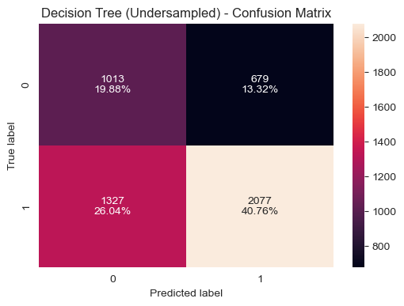

```
============================================================
2. Random Forest Classifier (Undersampled)
============================================================

Training Performance:
   Accuracy  Recall  Precision   F1
0       1.0     1.0        1.0  1.0

Test Performance:
   Accuracy   Recall  Precision        F1
0  0.677198  0.66745   0.815799  0.734206

Cross-validation F1-Score: 0.6857 (+/- 0.0165)
```

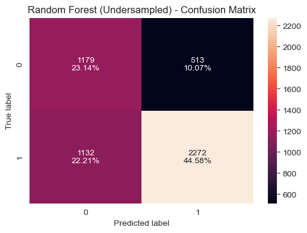

```
============================================================
3. Bagging Classifier (Undersampled)
============================================================

Training Performance:
   Accuracy    Recall  Precision        F1
0  0.980428  0.969572   0.991092  0.980214

Test Performance:
   Accuracy    Recall  Precision        F1
0  0.647567  0.609577   0.816286  0.697948

Cross-validation F1-Score: 0.6424 (+/- 0.0138)
```

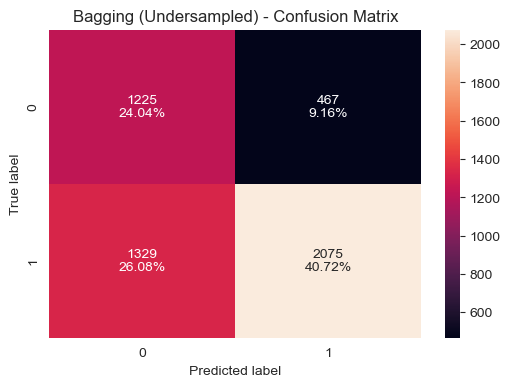

```
============================================================
4. AdaBoost Classifier (Undersampled)
============================================================

Training Performance:
   Accuracy    Recall  Precision     F1
0   0.70325  0.737223   0.690318  0.713

Test Performance:
   Accuracy    Recall  Precision        F1
0  0.694859  0.725911   0.798901  0.760659

Cross-validation F1-Score: 0.7072 (+/- 0.0210)
```

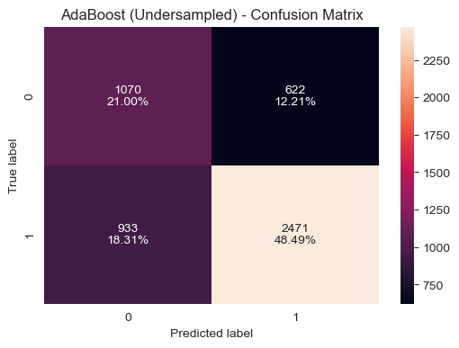

```
============================================================
5. Gradient Boosting Classifier (Undersampled)
============================================================

Training Performance:
   Accuracy    Recall  Precision       F1
0  0.719719  0.739143   0.711503  0.72506

Test Performance:
   Accuracy   Recall  Precision        F1
0  0.701138  0.71886   0.812147  0.762662

Cross-validation F1-Score: 0.7149 (+/- 0.0147)
```

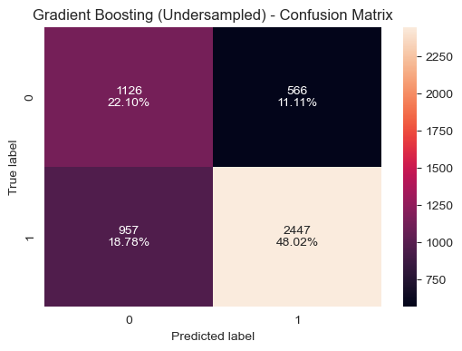

```
============================================================
6. XGBoost Classifier (Undersampled)
============================================================

Training Performance:
   Accuracy   Recall  Precision       F1
0  0.852733  0.85421   0.851694  0.85295

Test Performance:
   Accuracy    Recall  Precision        F1
0  0.679945  0.680082   0.810291  0.739498

Cross-validation F1-Score: 0.6897 (+/- 0.0108)
```

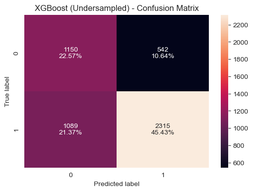

```
================================================================================
SUMMARY OF MODELS ON UNDERSAMPLED DATA
================================================================================
            Model  Train_F1  Test_F1  Train_Accuracy  Test_Accuracy  CV_F1_Score
Gradient Boosting  0.725060 0.762662        0.719719       0.701138     0.714852
         AdaBoost  0.713000 0.760659        0.703250       0.694859     0.707231
          XGBoost  0.852950 0.739498        0.852733       0.679945     0.689709
    Random Forest  1.000000 0.734206        1.000000       0.677198     0.685709
          Bagging  0.980214 0.697948        0.980428       0.647567     0.642437
    Decision Tree  1.000000 0.674351        1.000000       0.606358     0.621120
```

```python
# Apply Random Under-sampling
print("="*60)
print("APPLYING RANDOM UNDER-SAMPLING")
print("="*60)

undersampler = RandomUnderSampler(random_state=42)
X_train_undersampled, y_train_undersampled = undersampler.fit_resample(X_train, y_train)

print(f"Original training set shape: {X_train.shape}")
print(f"Undersampled training set shape: {X_train_undersampled.shape}")
print(f"\nOriginal target distribution:")
print(y_train.value_counts())
print(f"\nUndersampled target distribution:")
print(pd.Series(y_train_undersampled).value_counts())

# Dictionary to store model performances on undersampled data
models_undersampled = {}

# 1. Decision Tree Classifier on Undersampled Data
print("\n" + "="*60)
print("1. Decision Tree Classifier (Undersampled)")
print("="*60)
dt_us_model = DecisionTreeClassifier(random_state=42)
dt_us_model.fit(X_train_undersampled, y_train_undersampled)

dt_us_train_perf = model_performance_classification_sklearn(dt_us_model, X_train_undersampled, y_train_undersampled)
dt_us_test_perf = model_performance_classification_sklearn(dt_us_model, X_test, y_test)

print("\nTraining Performance:")
print(dt_us_train_perf)
print("\nTest Performance:")
print(dt_us_test_perf)

dt_us_cv_scores = cross_val_score(dt_us_model, X_train_undersampled, y_train_undersampled, cv=5, scoring=scorer)
print(f"\nCross-validation F1-Score: {dt_us_cv_scores.mean():.4f} (+/- {dt_us_cv_scores.std() * 2:.4f})")

models_undersampled['Decision Tree'] = {
    'model': dt_us_model,
    'train_perf': dt_us_train_perf,
    'test_perf': dt_us_test_perf,
    'cv_score': dt_us_cv_scores.mean()
}

confusion_matrix_sklearn(dt_us_model, X_test, y_test)
plt.title('Decision Tree (Undersampled) - Confusion Matrix')
plt.show()

# 2. Random Forest Classifier on Undersampled Data
print("\n" + "="*60)
print("2. Random Forest Classifier (Undersampled)")
print("="*60)
rf_us_model = RandomForestClassifier(n_estimators=100, random_state=42, n_jobs=-1)
rf_us_model.fit(X_train_undersampled, y_train_undersampled)

rf_us_train_perf = model_performance_classification_sklearn(rf_us_model, X_train_undersampled, y_train_undersampled)
rf_us_test_perf = model_performance_classification_sklearn(rf_us_model, X_test, y_test)

print("\nTraining Performance:")
print(rf_us_train_perf)
print("\nTest Performance:")
print(rf_us_test_perf)

rf_us_cv_scores = cross_val_score(rf_us_model, X_train_undersampled, y_train_undersampled, cv=5, scoring=scorer)
print(f"\nCross-validation F1-Score: {rf_us_cv_scores.mean():.4f} (+/- {rf_us_cv_scores.std() * 2:.4f})")

models_undersampled['Random Forest'] = {
    'model': rf_us_model,
    'train_perf': rf_us_train_perf,
    'test_perf': rf_us_test_perf,
    'cv_score': rf_us_cv_scores.mean()
}

confusion_matrix_sklearn(rf_us_model, X_test, y_test)
plt.title('Random Forest (Undersampled) - Confusion Matrix')
plt.show()

# 3. Bagging Classifier on Undersampled Data
print("\n" + "="*60)
print("3. Bagging Classifier (Undersampled)")
print("="*60)
bag_us_model = BaggingClassifier(random_state=42, n_jobs=-1)
bag_us_model.fit(X_train_undersampled, y_train_undersampled)

bag_us_train_perf = model_performance_classification_sklearn(bag_us_model, X_train_undersampled, y_train_undersampled)
bag_us_test_perf = model_performance_classification_sklearn(bag_us_model, X_test, y_test)

print("\nTraining Performance:")
print(bag_us_train_perf)
print("\nTest Performance:")
print(bag_us_test_perf)

bag_us_cv_scores = cross_val_score(bag_us_model, X_train_undersampled, y_train_undersampled, cv=5, scoring=scorer)
print(f"\nCross-validation F1-Score: {bag_us_cv_scores.mean():.4f} (+/- {bag_us_cv_scores.std() * 2:.4f})")

models_undersampled['Bagging'] = {
    'model': bag_us_model,
    'train_perf': bag_us_train_perf,
    'test_perf': bag_us_test_perf,
    'cv_score': bag_us_cv_scores.mean()
}

confusion_matrix_sklearn(bag_us_model, X_test, y_test)
plt.title('Bagging (Undersampled) - Confusion Matrix')
plt.show()

# 4. AdaBoost Classifier on Undersampled Data
print("\n" + "="*60)
print("4. AdaBoost Classifier (Undersampled)")
print("="*60)
ada_us_model = AdaBoostClassifier(random_state=42)
ada_us_model.fit(X_train_undersampled, y_train_undersampled)

ada_us_train_perf = model_performance_classification_sklearn(ada_us_model, X_train_undersampled, y_train_undersampled)
ada_us_test_perf = model_performance_classification_sklearn(ada_us_model, X_test, y_test)

print("\nTraining Performance:")
print(ada_us_train_perf)
print("\nTest Performance:")
print(ada_us_test_perf)

ada_us_cv_scores = cross_val_score(ada_us_model, X_train_undersampled, y_train_undersampled, cv=5, scoring=scorer)
print(f"\nCross-validation F1-Score: {ada_us_cv_scores.mean():.4f} (+/- {ada_us_cv_scores.std() * 2:.4f})")

models_undersampled['AdaBoost'] = {
    'model': ada_us_model,
    'train_perf': ada_us_train_perf,
    'test_perf': ada_us_test_perf,
    'cv_score': ada_us_cv_scores.mean()
}

confusion_matrix_sklearn(ada_us_model, X_test, y_test)
plt.title('AdaBoost (Undersampled) - Confusion Matrix')
plt.show()

# 5. Gradient Boosting Classifier on Undersampled Data
print("\n" + "="*60)
print("5. Gradient Boosting Classifier (Undersampled)")
print("="*60)
gb_us_model = GradientBoostingClassifier(random_state=42)
gb_us_model.fit(X_train_undersampled, y_train_undersampled)

gb_us_train_perf = model_performance_classification_sklearn(gb_us_model, X_train_undersampled, y_train_undersampled)
gb_us_test_perf = model_performance_classification_sklearn(gb_us_model, X_test, y_test)

print("\nTraining Performance:")
print(gb_us_train_perf)
print("\nTest Performance:")
print(gb_us_test_perf)

gb_us_cv_scores = cross_val_score(gb_us_model, X_train_undersampled, y_train_undersampled, cv=5, scoring=scorer)
print(f"\nCross-validation F1-Score: {gb_us_cv_scores.mean():.4f} (+/- {gb_us_cv_scores.std() * 2:.4f})")

models_undersampled['Gradient Boosting'] = {
    'model': gb_us_model,
    'train_perf': gb_us_train_perf,
    'test_perf': gb_us_test_perf,
    'cv_score': gb_us_cv_scores.mean()
}

confusion_matrix_sklearn(gb_us_model, X_test, y_test)
plt.title('Gradient Boosting (Undersampled) - Confusion Matrix')
plt.show()

# 6. XGBoost Classifier on Undersampled Data
print("\n" + "="*60)
print("6. XGBoost Classifier (Undersampled)")
print("="*60)
xgb_us_model = XGBClassifier(random_state=42, eval_metric='logloss')
xgb_us_model.fit(X_train_undersampled, y_train_undersampled)

xgb_us_train_perf = model_performance_classification_sklearn(xgb_us_model, X_train_undersampled, y_train_undersampled)
xgb_us_test_perf = model_performance_classification_sklearn(xgb_us_model, X_test, y_test)

print("\nTraining Performance:")
print(xgb_us_train_perf)
print("\nTest Performance:")
print(xgb_us_test_perf)

xgb_us_cv_scores = cross_val_score(xgb_us_model, X_train_undersampled, y_train_undersampled, cv=5, scoring=scorer)
print(f"\nCross-validation F1-Score: {xgb_us_cv_scores.mean():.4f} (+/- {xgb_us_cv_scores.std() * 2:.4f})")

models_undersampled['XGBoost'] = {
    'model': xgb_us_model,
    'train_perf': xgb_us_train_perf,
    'test_perf': xgb_us_test_perf,
    'cv_score': xgb_us_cv_scores.mean()
}

confusion_matrix_sklearn(xgb_us_model, X_test, y_test)
plt.title('XGBoost (Undersampled) - Confusion Matrix')
plt.show()

# Summary of models on undersampled data
print("\n" + "="*80)
print("SUMMARY OF MODELS ON UNDERSAMPLED DATA")
print("="*80)

summary_undersampled = []
for name, model_info in models_undersampled.items():
    summary_undersampled.append({
        'Model': name,
        'Train_F1': model_info['train_perf']['F1'].values[0],
        'Test_F1': model_info['test_perf']['F1'].values[0],
        'Train_Accuracy': model_info['train_perf']['Accuracy'].values[0],
        'Test_Accuracy': model_info['test_perf']['Accuracy'].values[0],
        'CV_F1_Score': model_info['cv_score']
    })

summary_df_undersampled = pd.DataFrame(summary_undersampled)
summary_df_undersampled = summary_df_undersampled.sort_values('Test_F1', ascending=False)
print(summary_df_undersampled.to_string(index=False))
```

## Hyperparameter Tuning

**Best practices for hyperparameter tuning in AdaBoost:**

`n_estimators`:

- Start with a specific number (50 is used in general) and increase in steps: 50, 75, 85, 100
- Use fewer estimators (e.g., 50 to 100) if using complex base learners (like deeper decision trees)
- Use more estimators (e.g., 100 to 150) when learning rate is low (e.g., 0.1 or lower)
- Avoid very high values unless performance keeps improving on validation

`learning_rate`:

- Common values to try: 1.0, 0.5, 0.1, 0.01
- Use 1.0 for faster training, suitable for fewer estimators
- Use 0.1 or 0.01 when using more estimators to improve generalization
- Avoid very small values (< 0.01) unless you plan to use many estimators (e.g., >500) and have sufficient data

**Best practices for hyperparameter tuning in Random Forest:**

`n_estimators`:

- Start with a specific number (50 is used in general) and increase in steps: 50, 75, 100, 125
- Higher values generally improve performance but increase training time
- Use 100-150 for large datasets or when variance is high

`min_samples_leaf`:

- Try values like: 1, 2, 4, 5, 10
- Higher values reduce model complexity and help prevent overfitting
- Use 1–2 for low-bias models, higher (like 5 or 10) for more regularized models
- Works well in noisy datasets to smooth predictions

`max_features`:

- Try values: `"sqrt"` (default for classification), `"log2"`, `None`, or float values (e.g., `0.3`, `0.5`)
- `"sqrt"` balances between diversity and performance for classification tasks
- Lower values (e.g., `0.3`) increase tree diversity, reducing overfitting
- Higher values (closer to `1.0`) may capture more interactions but risk overfitting

`max_samples` (for bootstrap sampling):

- Try float values between `0.5` to `1.0` or fixed integers
- Use `0.6–0.9` to introduce randomness and reduce overfitting
- Smaller values increase diversity between trees, improving generalization

**Best practices for hyperparameter tuning in Gradient Boosting:**

`n_estimators`:

- Start with 100 (default) and increase: 100, 200, 300, 500
- Typically, higher values lead to better performance, but they also increase training time
- Use 200–500 for larger datasets or complex problems
- Monitor validation performance to avoid overfitting, as too many estimators can degrade generalization

`learning_rate`:

- Common values to try: 0.1, 0.05, 0.01, 0.005
- Use lower values (e.g., 0.01 or 0.005) if you are using many estimators (e.g., > 200)
- Higher learning rates (e.g., 0.1) can be used with fewer estimators for faster convergence
- Always balance the learning rate with `n_estimators` to prevent overfitting or underfitting

`subsample`:

- Common values: 0.7, 0.8, 0.9, 1.0
- Use a value between `0.7` and `0.9` for improved generalization by introducing randomness
- `1.0` uses the full dataset for each boosting round, potentially leading to overfitting
- Reducing `subsample` can help reduce overfitting, especially in smaller datasets

`max_features`:

- Common values: `"sqrt"`, `"log2"`, or float (e.g., `0.3`, `0.5`)
- `"sqrt"` (default) works well for classification tasks
- Lower values (e.g., `0.3`) help reduce overfitting by limiting the number of features considered at each split

**Best practices for hyperparameter tuning in XGBoost:**

`n_estimators`:

- Start with 50 and increase in steps: 50,75,100,125.
- Use more estimators (e.g., 150-250) when using lower learning rates
- Monitor validation performance
- High values improve learning but increase training time

`subsample`:

- Common values: 0.5, 0.7, 0.8, 1.0
- Use `0.7–0.9` to introduce randomness and reduce overfitting
- `1.0` uses the full dataset in each boosting round; may overfit on small datasets
- Values < 0.5 are rarely useful unless dataset is very large

`gamma`:

- Try values: 0 (default), 1, 3, 5, 8
- Controls minimum loss reduction needed for a split
- Higher values make the algorithm more conservative (i.e., fewer splits)
- Use values > 0 to regularize and reduce overfitting, especially on noisy data

`colsample_bytree`:

- Try values: 0.3, 0.5, 0.7, 1.0
- Fraction of features sampled per tree
- Lower values (e.g., 0.3 or 0.5) increase randomness and improve generalization
- Use `1.0` when you want all features considered for every tree

`colsample_bylevel`:

- Try values: 0.3, 0.5, 0.7, 1.0
- Fraction of features sampled at each tree level (i.e., per split depth)
- Lower values help in regularization and reducing overfitting
- Often used in combination with `colsample_bytree` for fine control over feature sampling

```
================================================================================
COMPARING ALL MODELS TO SELECT TOP 3 FOR HYPERPARAMETER TUNING
================================================================================

All Models Performance Summary (sorted by Test F1-Score):
                           Model    Data_Type  Test_F1  Test_Accuracy    CV_F1
    Gradient Boosting (Original)     Original 0.819446       0.742739 0.822767
             AdaBoost (Original)     Original 0.814454       0.730965 0.818841
              XGBoost (Original)     Original 0.807831       0.728414 0.809336
        Random Forest (Original)     Original 0.800840       0.720761 0.801602
           XGBoost (Oversampled)  Oversampled 0.795872       0.720565 0.785648
 Gradient Boosting (Oversampled)  Oversampled 0.779604       0.715856 0.737637
              Bagging (Original)     Original 0.771771       0.693485 0.772693
     Random Forest (Oversampled)  Oversampled 0.770560       0.697802 0.778024
Gradient Boosting (Undersampled) Undersampled 0.762662       0.701138 0.714852
         AdaBoost (Undersampled) Undersampled 0.760659       0.694859 0.707231
          AdaBoost (Oversampled)  Oversampled 0.757970       0.693093 0.714419
        Decision Tree (Original)     Original 0.742748       0.655416 0.746284
          XGBoost (Undersampled) Undersampled 0.739498       0.679945 0.689709
           Bagging (Oversampled)  Oversampled 0.736348       0.669349 0.731450
    Random Forest (Undersampled) Undersampled 0.734206       0.677198 0.685709
     Decision Tree (Oversampled)  Oversampled 0.726140       0.646389 0.704630
          Bagging (Undersampled) Undersampled 0.697948       0.647567 0.642437
    Decision Tree (Undersampled) Undersampled 0.674351       0.606358 0.621120

================================================================================
TOP 3 MODELS SELECTED FOR HYPERPARAMETER TUNING:
================================================================================
                       Model  Test_F1    CV_F1
Gradient Boosting (Original) 0.819446 0.822767
         AdaBoost (Original) 0.814454 0.818841
          XGBoost (Original) 0.807831 0.809336

Selected models for hyperparameter tuning:
1. Gradient Boosting (Original)
2. AdaBoost (Original)
3. XGBoost (Original)

================================================================================
1. RANDOM FOREST HYPERPARAMETER TUNING
================================================================================
Tuning Random Forest on Original data
Fitting 5 folds for each of 108 candidates, totalling 540 fits

Best parameters: {'max_features': 'log2', 'max_samples': 0.6, 'min_samples_leaf': 4, 'n_estimators': 125}
Best CV F1-Score: 0.8234

Test Performance:
   Accuracy    Recall  Precision        F1
0  0.740777  0.877791   0.767531  0.818967
```

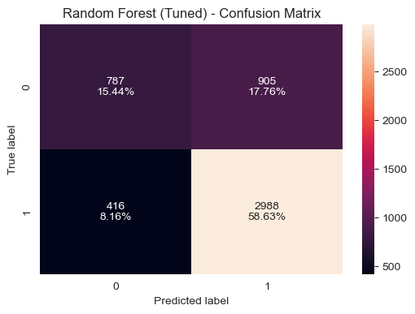

```python
# Compare all models and select top 3 for hyperparameter tuning
print("="*80)
print("COMPARING ALL MODELS TO SELECT TOP 3 FOR HYPERPARAMETER TUNING")
print("="*80)

# Combine all model results
all_models_summary = []

# Original data models
for name, model_info in models_original.items():
    all_models_summary.append({
        'Model': f'{name} (Original)',
        'Data_Type': 'Original',
        'Test_F1': model_info['test_perf']['F1'].values[0],
        'Test_Accuracy': model_info['test_perf']['Accuracy'].values[0],
        'CV_F1': model_info['cv_score']
    })

# Oversampled data models
for name, model_info in models_oversampled.items():
    all_models_summary.append({
        'Model': f'{name} (Oversampled)',
        'Data_Type': 'Oversampled',
        'Test_F1': model_info['test_perf']['F1'].values[0],
        'Test_Accuracy': model_info['test_perf']['Accuracy'].values[0],
        'CV_F1': model_info['cv_score']
    })

# Undersampled data models
for name, model_info in models_undersampled.items():
    all_models_summary.append({
        'Model': f'{name} (Undersampled)',
        'Data_Type': 'Undersampled',
        'Test_F1': model_info['test_perf']['F1'].values[0],
        'Test_Accuracy': model_info['test_perf']['Accuracy'].values[0],
        'CV_F1': model_info['cv_score']
    })

all_models_df = pd.DataFrame(all_models_summary)
all_models_df = all_models_df.sort_values('Test_F1', ascending=False)

print("\nAll Models Performance Summary (sorted by Test F1-Score):")
print(all_models_df.to_string(index=False))

# Select top 3 models based on Test F1-Score
top_3_models = all_models_df.head(3)
print("\n" + "="*80)
print("TOP 3 MODELS SELECTED FOR HYPERPARAMETER TUNING:")
print("="*80)
print(top_3_models[['Model', 'Test_F1', 'CV_F1']].to_string(index=False))

# Store top 3 model names for tuning
top_3_model_names = top_3_models['Model'].tolist()
print("\nSelected models for hyperparameter tuning:")
for i, model_name in enumerate(top_3_model_names, 1):
    print(f"{i}. {model_name}")

# Initialize tuned_models dictionary
tuned_models = {}

# 1. Random Forest Hyperparameter Tuning
print("\n" + "="*80)
print("1. RANDOM FOREST HYPERPARAMETER TUNING")
print("="*80)

# Use the best data type for Random Forest (check top_3_models)
rf_best_type = top_3_models[top_3_models['Model'].str.contains('Random Forest')]['Data_Type'].values[0] if len(top_3_models[top_3_models['Model'].str.contains('Random Forest')]) > 0 else 'Original'

if rf_best_type == 'Oversampled':
    X_tune, y_tune = X_train_oversampled, y_train_oversampled
elif rf_best_type == 'Undersampled':
    X_tune, y_tune = X_train_undersampled, y_train_undersampled
else:
    X_tune, y_tune = X_train, y_train

print(f"Tuning Random Forest on {rf_best_type} data")

# Parameter grid for Random Forest
rf_param_grid = {
    'n_estimators': [100, 125, 150],
    'min_samples_leaf': [1, 2, 4, 5],
    'max_features': ['sqrt', 'log2', 0.3],
    'max_samples': [0.6, 0.8, 1.0]
}

rf_grid = GridSearchCV(
    RandomForestClassifier(random_state=42, n_jobs=-1),
    param_grid=rf_param_grid,
    scoring=scorer,
    cv=5,
    n_jobs=-1,
    verbose=1
)

rf_grid.fit(X_tune, y_tune)

print(f"\nBest parameters: {rf_grid.best_params_}")
print(f"Best CV F1-Score: {rf_grid.best_score_:.4f}")

# Evaluate on test set
rf_tuned = rf_grid.best_estimator_
rf_tuned_test_perf = model_performance_classification_sklearn(rf_tuned, X_test, y_test)
print("\nTest Performance:")
print(rf_tuned_test_perf)

tuned_models['Random Forest'] = {
    'model': rf_tuned,
    'best_params': rf_grid.best_params_,
    'cv_score': rf_grid.best_score_,
    'test_perf': rf_tuned_test_perf
}

confusion_matrix_sklearn(rf_tuned, X_test, y_test)
plt.title('Random Forest (Tuned) - Confusion Matrix')
plt.show()
```

```
================================================================================
2. GRADIENT BOOSTING HYPERPARAMETER TUNING
================================================================================
Tuning Gradient Boosting on Original data
Fitting 5 folds for each of 81 candidates, totalling 405 fits

Best parameters: {'learning_rate': 0.1, 'max_features': 'log2', 'n_estimators': 100, 'subsample': 0.9}
Best CV F1-Score: 0.8236

Test Performance:
   Accuracy    Recall  Precision        F1
0   0.73646  0.866334   0.768569  0.814528
```

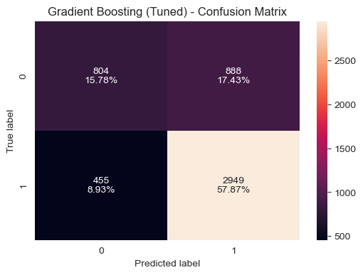

```python
# 2. Gradient Boosting Hyperparameter Tuning
print("\n" + "="*80)
print("2. GRADIENT BOOSTING HYPERPARAMETER TUNING")
print("="*80)

# Use the best data type for Gradient Boosting
gb_best_type = top_3_models[top_3_models['Model'].str.contains('Gradient Boosting')]['Data_Type'].values[0] if len(top_3_models[top_3_models['Model'].str.contains('Gradient Boosting')]) > 0 else 'Original'

if gb_best_type == 'Oversampled':
    X_tune, y_tune = X_train_oversampled, y_train_oversampled
elif gb_best_type == 'Undersampled':
    X_tune, y_tune = X_train_undersampled, y_train_undersampled
else:
    X_tune, y_tune = X_train, y_train

print(f"Tuning Gradient Boosting on {gb_best_type} data")

# Parameter grid for Gradient Boosting
gb_param_grid = {
    'n_estimators': [100, 200, 300],
    'learning_rate': [0.05, 0.1, 0.15],
    'subsample': [0.7, 0.8, 0.9],
    'max_features': ['sqrt', 'log2', 0.3]
}

gb_grid = GridSearchCV(
    GradientBoostingClassifier(random_state=42),
    param_grid=gb_param_grid,
    scoring=scorer,
    cv=5,
    n_jobs=-1,
    verbose=1
)

gb_grid.fit(X_tune, y_tune)

print(f"\nBest parameters: {gb_grid.best_params_}")
print(f"Best CV F1-Score: {gb_grid.best_score_:.4f}")

# Evaluate on test set
gb_tuned = gb_grid.best_estimator_
gb_tuned_test_perf = model_performance_classification_sklearn(gb_tuned, X_test, y_test)
print("\nTest Performance:")
print(gb_tuned_test_perf)

tuned_models['Gradient Boosting'] = {
    'model': gb_tuned,
    'best_params': gb_grid.best_params_,
    'cv_score': gb_grid.best_score_,
    'test_perf': gb_tuned_test_perf
}

confusion_matrix_sklearn(gb_tuned, X_test, y_test)
plt.title('Gradient Boosting (Tuned) - Confusion Matrix')
plt.show()
```